# Feature Metadata Analysis

Christina Schmidt

Heidelberg University

Jannik Franken

Heidelberg University

```r
# 1. Install Rtools if you haven’t done this yet, using the appropriate version (e.g.windows or macOS).
# 2. Install the latest development version from GitHub using devtools
# devtools::install_github("https://github.com/saezlab/MetaProViz")

#remotes::install_github('saezlab/OmnipathR@devel')
#remotes::install_github("saezlab/MetaProViz@devel")
library(MetaProViz)

# dependencies that need to be loaded:
library(magrittr)
library(dplyr)
library(rlang)
library(tidyr)
library(tibble)
library(stringr)
```

```r
# Make folder for results:
if (!dir.exists("MetaProViz_Results/PK")) {
  dir.create("MetaProViz_Results/PK", recursive = TRUE)
}

if (!dir.exists("MetaProViz_Results/PK/ID_QC")) {
  dir.create("MetaProViz_Results/PK/ID_QC", recursive = TRUE)
}

if (!dir.exists("MetaProViz_Results/PK/Original")) {
  dir.create("MetaProViz_Results/PK/Original", recursive = TRUE)
}

if (!dir.exists("MetaProViz_Results/PK/Cleaned")) {
  dir.create("MetaProViz_Results/PK/Cleaned", recursive = TRUE)
}

if (!dir.exists("MetaProViz_Results/PK/Translated")) {
  dir.create("MetaProViz_Results/PK/Translated", recursive = TRUE)
}

if (!dir.exists("MetaProViz_Results/PK/Traverse")) {
  dir.create("MetaProViz_Results/PK/Traverse", recursive = TRUE)
}

if (!dir.exists("MetaProViz_Results/PK/EquivalentID")) {
  dir.create("MetaProViz_Results/PK/EquivalentID", recursive = TRUE)
}

if (!dir.exists("MetaProViz_Results/PK/id_summary")) {
  dir.create("MetaProViz_Results/PK/id_summary", recursive = TRUE)
}

##------------------------------------------------------------------
# Individual DBs
## HMDB
if (!dir.exists("MetaProViz_Results/PK/PK_HMDB")) {
  dir.create("MetaProViz_Results/PK/PK_HMDB", recursive = TRUE)
}

if (!dir.exists("MetaProViz_Results/PK/PK_HMDB/Original")) {
  dir.create("MetaProViz_Results/PK/PK_HMDB/Original", recursive = TRUE)
}

if (!dir.exists("MetaProViz_Results/PK/PK_HMDB/Cleaned")) {
  dir.create("MetaProViz_Results/PK/PK_HMDB/Cleaned", recursive = TRUE)
}

if (!dir.exists("MetaProViz_Results/PK/PK_HMDB/Translated")) {
  dir.create("MetaProViz_Results/PK/PK_HMDB/Translated", recursive = TRUE)
}

if (!dir.exists("MetaProViz_Results/PK/PK_HMDB/Traverse")) {
  dir.create("MetaProViz_Results/PK/PK_HMDB/Traverse", recursive = TRUE)
}

if (!dir.exists("MetaProViz_Results/PK/PK_HMDB/EquivalentID")) {
  dir.create("MetaProViz_Results/PK/PK_HMDB/EquivalentID", recursive = TRUE)
}

## KEGG
if (!dir.exists("MetaProViz_Results/PK/PK_KEGG")) {
  dir.create("MetaProViz_Results/PK/PK_KEGG", recursive = TRUE)
}

if (!dir.exists("MetaProViz_Results/PK/PK_KEGG/Original")) {
  dir.create("MetaProViz_Results/PK/PK_KEGG/Original", recursive = TRUE)
}

if (!dir.exists("MetaProViz_Results/PK/PK_KEGG/Cleaned")) {
  dir.create("MetaProViz_Results/PK/PK_KEGG/Cleaned", recursive = TRUE)
}

if (!dir.exists("MetaProViz_Results/PK/PK_KEGG/Translated")) {
  dir.create("MetaProViz_Results/PK/PK_KEGG/Translated", recursive = TRUE)
}

if (!dir.exists("MetaProViz_Results/PK/PK_KEGG/Traverse")) {
  dir.create("MetaProViz_Results/PK/PK_KEGG/Traverse", recursive = TRUE)
}

if (!dir.exists("MetaProViz_Results/PK/PK_KEGG/EquivalentID")) {
  dir.create("MetaProViz_Results/PK/PK_KEGG/EquivalentID", recursive = TRUE)
}

## PUBCHEM
if (!dir.exists("MetaProViz_Results/PK/PK_PUBCHEM")) {
  dir.create("MetaProViz_Results/PK/PK_PUBCHEM", recursive = TRUE)
}

if (!dir.exists("MetaProViz_Results/PK/PK_PUBCHEM/Original")) {
  dir.create("MetaProViz_Results/PK/PK_PUBCHEM/Original", recursive = TRUE)
}

if (!dir.exists("MetaProViz_Results/PK/PK_PUBCHEM/Cleaned")) {
  dir.create("MetaProViz_Results/PK/PK_PUBCHEM/Cleaned", recursive = TRUE)
}

if (!dir.exists("MetaProViz_Results/PK/PK_PUBCHEM/Translated")) {
  dir.create("MetaProViz_Results/PK/PK_PUBCHEM/Translated", recursive = TRUE)
}

if (!dir.exists("MetaProViz_Results/PK/PK_PUBCHEM/Traverse")) {
  dir.create("MetaProViz_Results/PK/PK_PUBCHEM/Traverse", recursive = TRUE)
}

if (!dir.exists("MetaProViz_Results/PK/PK_PUBCHEM/EquivalentID")) {
  dir.create("MetaProViz_Results/PK/PK_PUBCHEM/EquivalentID", recursive = TRUE)
}

## CHEBI
if (!dir.exists("MetaProViz_Results/PK/PK_CHEBI")) {
  dir.create("MetaProViz_Results/PK/PK_CHEBI", recursive = TRUE)
}

if (!dir.exists("MetaProViz_Results/PK/PK_CHEBI/Traverse")) {
  dir.create("MetaProViz_Results/PK/PK_CHEBI/Traverse", recursive = TRUE)
}

if (!dir.exists("MetaProViz_Results/PK/PK_CHEBI/EquivalentID")) {
  dir.create("MetaProViz_Results/PK/PK_CHEBI/EquivalentID", recursive = TRUE)
}
```

# 1. Loading the Feature metadata

Here we choose an example datasets, which is publicly available in the paper “An Integrated Metabolic Atlas of Clear Cell Renal Cell Carcinoma”, which includes metabolomic profiling on 138 matched clear cell renal cell carcinoma (ccRCC)/normal tissue pairs (Hakimi et al. 2016). Metabolomics was done using The company Metabolon, so this is untargeted metabolomics.  
We have updated the PubChem IDs as there were PubChem entries in the excel file that are not PubChem IDs. It is likely that this is an error caused by excel conversion as it seems in some cases the first part of the ID corresponds to one of the other IDs, so maybe these where multiple potential PubChem IDs.To see details on how this was done check out our example data branch: https://github.com/saezlab/MetaProViz/blob/ExampleData/ccRCC_Hakimi-et-all.html

Load the feature metadata:

```r
data(tissue_meta)

# Global separator convention for all metabolite ID columns
id_separator <- ", "

# Normalize mixed separators (",", ";") to one global format
normalize_id_cell <- function(x, out_sep = id_separator) {
  ifelse(
    is.na(x),
    NA_character_,
    purrr::map_chr(stringr::str_split(x, "[;,]"), ~ {
      vals <- stringr::str_trim(.x)
      vals <- vals[vals != ""]
      if (length(vals) == 0) NA_character_ else paste(vals, collapse = out_sep)
    })
  )
}

MetaboliteIDs <- tissue_meta %>%
  dplyr::filter(!stringr::str_detect(Metabolite, "^X\\s*-\\s*\\d+$"))%>%# only keep entries with trivial names
   dplyr::mutate(
    SUPER_PATHWAY = dplyr::coalesce(SUPER_PATHWAY, "None"),
    SUB_PATHWAY   = dplyr::coalesce(SUB_PATHWAY, "None"),
    CAS = normalize_id_cell(CAS),
    HMDB = normalize_id_cell(HMDB),
    KEGG = normalize_id_cell(KEGG),
    PUBCHEM = normalize_id_cell(PUBCHEM)
  )

# make sure there are no more semicolons in any cell of the MetaboliteIDs df
# because this will become a problem in the csv file saving

MetaboliteIDs <- MetaboliteIDs %>%
  mutate(across(where(is.character), ~ gsub(";", ",", .x)))

## save as csv
write.csv2(
  MetaboliteIDs,
  "MetaProViz_Results/PK/Original/Metabolite_IDs_original.csv"
)
```

# 2. MetaProViz Metabolite ID workflow

## Original Feature Space Exploration

1. Present metabolite IDs:

```r
ccRCC_CompareIDs <- MetaProViz::compare_pk(data = list(Biocft = MetaboliteIDs |> dplyr::rename("Class"="SUPER_PATHWAY")),
                                           name_col = "Metabolite",
                                           metadata_info = list(Biocft = c("KEGG", "HMDB", "PUBCHEM")),
                                           plot_name = "Overlap of ID types in ccRCC data",
                                           path= "MetaProViz_Results/PK/Original")
```

```
#> Note: Could not render upset plot to screen due to theme compatibility issues. Plot was saved to file successfully.
```

Here we notice that 76 features have no metabolite ID assigned, yet have a trivial name and a metabolite class assigned. For 135 metabolites we only have a pubchem ID, yet no HMDB or KEGG ID.

2.1. HMDB:

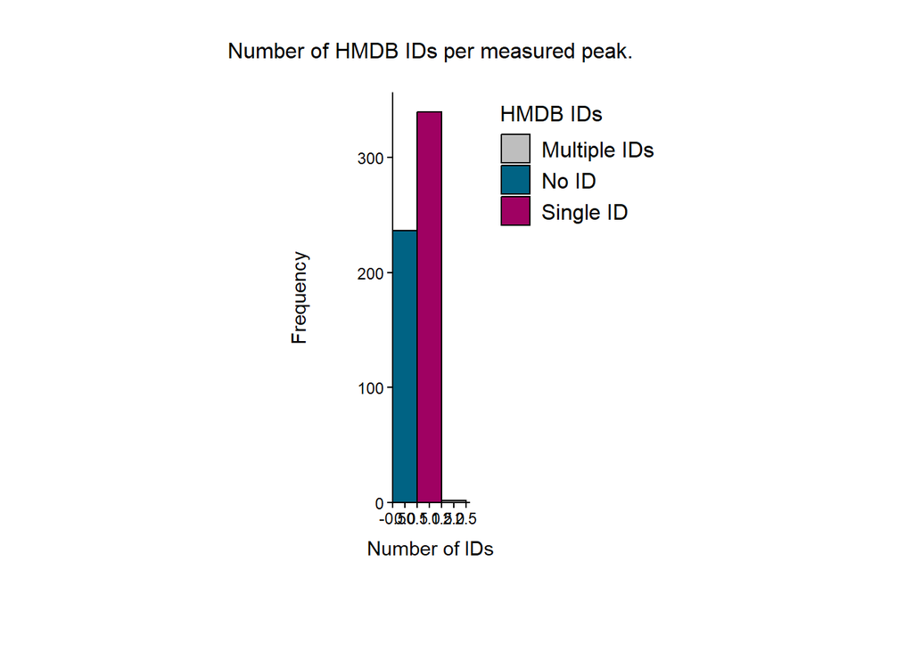

```r
Plot1_HMDB <- MetaProViz::count_id(MetaboliteIDs,
                                   delimiter = id_separator,
                                   "HMDB",
                                   fill_colors = c(`No ID` = "#006384", `Single ID` = "#9F0162", `Multiple IDs` = "#BEBEBE"),
                                   path = "MetaProViz_Results/PK/PK_HMDB/Original")
```

2.2. KEGG:

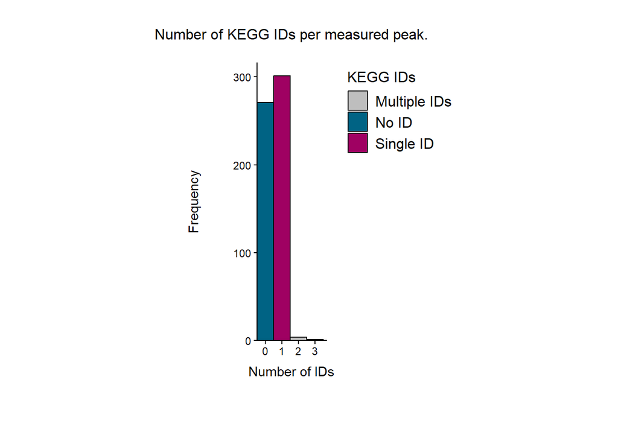

```r
Plot1_KEGG <- MetaProViz::count_id(MetaboliteIDs,
                                   delimiter = id_separator,
                                   fill_colors = c(`No ID` = "#006384", `Single ID` = "#9F0162", `Multiple IDs` = "#BEBEBE"),
                                   "KEGG",
                                   path= "MetaProViz_Results/PK/PK_KEGG/Original")
```

2.3.: PubChem:

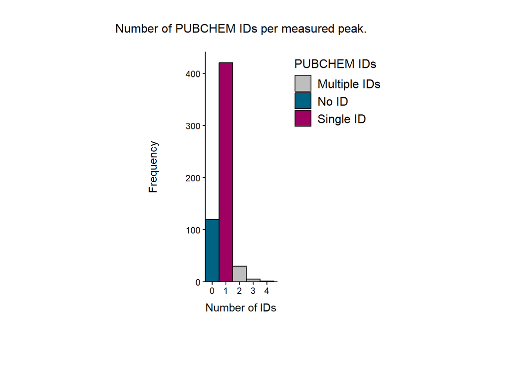

```r
Plot1_PubChem <- MetaProViz::count_id(MetaboliteIDs,
                                   delimiter = id_separator,
                                   fill_colors = c(`No ID` = "#006384", `Single ID` = "#9F0162", `Multiple IDs` = "#BEBEBE"),
                                   "PUBCHEM",
                                   path= "MetaProViz_Results/PK/PK_PUBCHEM/Original")
```

```r
########################
### HELPER functions for id_summary table and deltas

## Helper: extract one summary row from count_id() output
extract_id_counts <- function(count_obj, row_name) {
  ## count_obj must be an object returned by MetaProViz::count_id()

  tbl <- count_obj$Table

  ## Count how many features fall into each ID class
  counts_wide <- tbl %>%
    count(id_label, name = "n") %>%
    mutate(
      id_label = recode(
        id_label,
        "No ID" = "no_ID",
        "Single ID" = "Single_ID",
        "Multiple IDs" = "Multiple_IDs"
      )
    ) %>%
    pivot_wider(
      names_from = id_label,
      values_from = n,
      values_fill = 0
    )

  ## Make sure all expected columns exist
  ## This avoids errors if one class is absent in a given dataset
  for (col in c("no_ID", "Single_ID", "Multiple_IDs")) {
    if (!col %in% names(counts_wide)) {
      counts_wide[[col]] <- 0L
    }
  }

  ## Build one clean summary row
  tibble(
    row_name = row_name,
    no_ID = as.integer(counts_wide$no_ID[1]),
    Single_ID = as.integer(counts_wide$Single_ID[1]),
    Multiple_IDs = as.integer(counts_wide$Multiple_IDs[1]),
    Total_IDs = as.integer(sum(tbl$entry_count, na.rm = TRUE))
  )
}



## Helper: append one summary row to id_count_df
append_id_counts <- function(df, count_obj, row_name) {
  bind_rows(df, extract_id_counts(count_obj, row_name))
}

## Helper: calculate deltas within each database only

## Example:
## HMDB_cleaned - HMDB_Original
## KEGG_cleaned - KEGG_Original
## PUBCHEM_cleaned - PUBCHEM_Original

## This does not compare across databases.
calculate_id_deltas <- function(df, from_category, to_category) {

  df %>%
    separate(row_name, into = c("id_type", "category"), sep = "_", remove = FALSE) %>%
    select(-row_name) %>%
    pivot_wider(
      names_from = category,
      values_from = c(no_ID, Single_ID, Multiple_IDs, Total_IDs)
    ) %>%
    transmute(
      row_name = paste0("delta_", id_type, "_", from_category, "_", id_type, "_", to_category),
      no_ID = .data[[paste0("no_ID_", to_category)]] - .data[[paste0("no_ID_", from_category)]],
      Single_ID = .data[[paste0("Single_ID_", to_category)]] - .data[[paste0("Single_ID_", from_category)]],
      Multiple_IDs = .data[[paste0("Multiple_IDs_", to_category)]] - .data[[paste0("Multiple_IDs_", from_category)]],
      Total_IDs = .data[[paste0("Total_IDs_", to_category)]] - .data[[paste0("Total_IDs_", from_category)]]
    )
}

## Helper: count features with no HMDB, KEGG, or PUBCHEM
## This works on the original category dataframe, not on count_id() output.
## Example inputs:  MetaboliteIDs    or   MetaboliteID_Translated
count_none_all_ids <- function(df) {
  sum(
    (is.na(df$HMDB)    | trimws(as.character(df$HMDB)) %in% c("", "NA")) &
    (is.na(df$KEGG)    | trimws(as.character(df$KEGG)) %in% c("", "NA")) &
    (is.na(df$PUBCHEM) | trimws(as.character(df$PUBCHEM)) %in% c("", "NA")),
    na.rm = TRUE
  )
}

## Helper: append one row to none_summary_df
append_none_summary <- function(df, input_df, row_name) {
  bind_rows(
    df,
    tibble(
      row_name = row_name,
      No_database_ID = as.integer(count_none_all_ids(input_df))
    )
  )
}

## Helper: calculate delta for the "none at all" summary
## Example:  ## cleaned - Original
calculate_none_delta <- function(df, from_category, to_category) {

  tibble(
    row_name = paste0("delta_", from_category, "_", to_category),
    No_database_ID =
      df$No_database_ID[df$row_name == to_category] -
      df$No_database_ID[df$row_name == from_category]
  )
}
```

```r
## Initialise the main per-database summary dataframe

## This table stores one row per database and category, for example:
## HMDB_Original, KEGG_cleaned, PUBCHEM_Original, etc.
##
## Column meanings:
## no_ID         = number of features with no ID in that database
## Single_ID     = number of features with exactly one ID in that database
## Multiple_IDs  = number of features with more than one ID in that database
## Total_IDs     = total number of IDs assigned in that database
##                 calculated as sum(entry_count)

id_count_df <- tibble(
  row_name      = character(),
  no_ID         = integer(),
  Single_ID     = integer(),
  Multiple_IDs  = integer(),
  Total_IDs     = integer()
)



## Fill the main table with categories

## Original
id_count_df <- append_id_counts(id_count_df, Plot1_HMDB,    "HMDB_Original")
id_count_df <- append_id_counts(id_count_df, Plot1_KEGG,    "KEGG_Original")
id_count_df <- append_id_counts(id_count_df, Plot1_PubChem, "PUBCHEM_Original")


# how to go on after a new version of the data:

# ## cleaned
# id_count_df <- append_id_counts(id_count_df, Plot2_HMDB,    "HMDB_cleaned")
# id_count_df <- append_id_counts(id_count_df, Plot2_KEGG,    "KEGG_cleaned")
# id_count_df <- append_id_counts(id_count_df, Plot2_PubChem, "PUBCHEM_cleaned")
#
#
# ## Calculate delta rows
# delta_df <- calculate_id_deltas(id_count_df, "Original", "cleaned")
#
# when doing this the second time, append a new row to delta_df instead of overwriting it


# ONLY at the very end: append delta rows into the main summary table
# id_count_df <- bind_rows(id_count_df, delta_df)


## Initialise the cross-database "none at all" summary

## This is a separate dataframe because it is not database-specific.
## It counts features with no HMDB, no KEGG, and no PUBCHEM whatsoever.
none_summary_df <- tibble(
  row_name = character(),
  No_database_ID = integer()
)


## Fill the cross-database summary table

## Original category dataframe
none_summary_df <- append_none_summary(none_summary_df, MetaboliteIDs, "Original")

## how to go on with a new version of the data:
#
# ## cleaned category dataframe
# none_summary_df <- append_none_summary(none_summary_df, MetaboliteID_Translated, "cleaned")
#
# ## Calculate delta row
# none_delta_df <- calculate_none_delta(none_summary_df, "Original", "cleaned")
#
# ## Optional: append delta row into the summary table
# none_summary_df <- bind_rows(none_summary_df, none_delta_df)



## Final objects
## id_count_df:
## per-database summary including optional delta rows
##
## none_summary_df:
## category-level count of features with no HMDB, KEGG, or PUBCHEM at all,
## including optional delta row

id_count_df
```

```
#> # A tibble: 3 × 5
#>   row_name         no_ID Single_ID Multiple_IDs Total_IDs
#>   <chr>            <int>     <int>        <int>     <int>
#> 1 HMDB_Original      236       339            2       343
#> 2 KEGG_Original      271       301            5       312
#> 3 PUBCHEM_Original   120       420           37       503
```

```r
none_summary_df
```

```
#> # A tibble: 1 × 2
#>   row_name No_database_ID
#>   <chr>             <int>
#> 1 Original             76
```

3.ID compatibility check

```r
MetaboliteIDs_compatibility_check <- seed_id_compatibility_check(
    data = MetaboliteIDs,
    id_types = c("HMDB", "KEGG", "CHEBI", "PUBCHEM"),
    delimiter = ","
)
##  Note: the compatibility check does not assess CAS ID compatibility
## Note: The input df does not contain ChEBI IDs. For the compatibility check,
##       ChEBI IDs are internally used as possible stepstones for ID compatibility

## Look at the compatibility check results
MetaboliteIDs_pair_compatibility <- MetaboliteIDs_compatibility_check$ID_pair_compatibility
MetaboliteIDs_data_with_compatibility <- MetaboliteIDs_compatibility_check$data_with_compatibility

## how many features of the "MetaboliteIDs" df have a completely compatible list of IDs? (only considering PUBCHEM, KEGG & HMDB)
cat("Fully compatible features (PUBCHEM/KEGG/HMDB):", length(which(MetaboliteIDs_data_with_compatibility$all_seed_ids_compatible == TRUE)), "\n")
```

```
#> Fully compatible features (PUBCHEM/KEGG/HMDB): 503
```

```r
## how many features are not completely compatible (can still have partial compatibility)?
cat("Not fully compatible features (can still be partially compatible):", length(which(MetaboliteIDs_data_with_compatibility$all_seed_ids_compatible == FALSE)), "\n")
```

```
#> Not fully compatible features (can still be partially compatible): 74
```

```r
## for all ID pairs across features,
## how many direct matches were there?
cat("ID-pair direct matches:", length(which(MetaboliteIDs_pair_compatibility$compatibility_path == "direct")), "\n")
```

```
#> ID-pair direct matches: 790
```

```r
## how many secondary matches were there?
cat("ID-pair secondary matches:", length(which(MetaboliteIDs_pair_compatibility$compatibility_path == "secondary")), "\n")
```

```
#> ID-pair secondary matches: 47
```

```r
## how many were no_match? -> these contain rows, which only had CAS or only one of HMDB, KEGG, PUBCHEM but not two
cat("ID-pair no_match cases:", length(which(MetaboliteIDs_pair_compatibility$compatibility_path == "no_match")), "\n")
```

```
#> ID-pair no_match cases: 351
```

```r
## assess ID compatibility and remove incompatible IDs


#   go through the pair_compatibility permutation table
#   Question: do we exclude all incompatible ID pairs?
#       - sometimes there is less than two HMDB, KEGG, PUBCHEM seed IDs.
#         Maybe there is only a CAS or only one of the other ID types.
#         In this case, we don't want to exclude them, because we can not really
#         assess compatibility. Therefore, "all_seed_ids_compatible" is TRUE
#         -> keep all where "all_seed_ids_compatible" == TRUE
#       - in the Results_Traverse$ID_pair_compatibility (traverse_ID_pair_compatibility),
#         we have the column "original_row_id" to re-group seed_id-pairs later
#       - if we need to exclude seed_id combinations without a match for all rows where
#         "all_seed_ids_compatible" == FALSE, we may loose a lot of pairs and even whole features
#       - decide what to do for partially-compatible features
#       - manually decide for features with multiple, all-incompatible IDs (this is the most important point here)

## a good example is original_row_id == 99 of the original df, the metabolite 4-hydroxyglutamate

# > MetaboliteIDs_pair_compatibility[MetaboliteIDs_pair_compatibility$"original_row_id" == "99", ]

#   original_row_id Metabolite   CAS   SUPER_PATHWAY  ...   PUBCHEM KEGG  HMDB  CHEBI row_id seed1_type seed1_id seed2_type seed2_id pair_compatible compatibility_path n_seed_ids all_seed_ids_compatible
#   <chr>           <chr>        <chr> <chr>          ...   <chr>   <chr> <chr> <chr>  <int> <chr>      <chr>    <chr>      <chr>    <lgl>           <chr>                   <int> <lgl>
# 1 99              4-hydroxygl~ 2485~ Amino acid     ...   546007~ C030~ HMDB~ NA        99 HMDB       HMDB000~ KEGG       C03079   FALSE           no_match                    4 FALSE
# 2 99              4-hydroxygl~ 2485~ Amino acid     ...   546007~ C030~ HMDB~ NA        99 HMDB       HMDB000~ PUBCHEM    5460078  FALSE           no_match                    4 FALSE
# 3 99              4-hydroxygl~ 2485~ Amino acid     ...   546007~ C030~ HMDB~ NA        99 HMDB       HMDB000~ PUBCHEM    5460800  FALSE           no_match                    4 FALSE
# 4 99              4-hydroxygl~ 2485~ Amino acid     ...   546007~ C030~ HMDB~ NA        99 KEGG       C03079   PUBCHEM    5460078  TRUE            direct                      4 FALSE
# 5 99              4-hydroxygl~ 2485~ Amino acid     ...   546007~ C030~ HMDB~ NA        99 KEGG       C03079   PUBCHEM    5460800  TRUE            direct                      4 FALSE
# 6 99              4-hydroxygl~ 2485~ Amino acid     ...   546007~ C030~ HMDB~ NA        99 PUBCHEM    5460078  PUBCHEM    5460800  TRUE            secondary                   4 FALSE

# this would be a partially compatible feature

## here, we have "all_seed_ids_compatible" == FALSE, but we want to keep some of the combinations
## we also have no_match direct and secondary matches, which makes it a good example


## What if we we were to keep all direct and secondary matches and discard no_match?

MetaboliteIDs_pair_compatibility_filtered <- MetaboliteIDs_pair_compatibility %>%
  filter(
    (all_seed_ids_compatible == TRUE) |
    (all_seed_ids_compatible == FALSE & compatibility_path == "direct") |
    (all_seed_ids_compatible == FALSE & compatibility_path == "secondary")
  )


# let's assess, if we lost any whole features due to this filtering
## these are these features:
cat("Distinct metabolites before compatibility filtering:", length(unique(MetaboliteIDs_pair_compatibility$Metabolite)), "\n")
```

```
#> Distinct metabolites before compatibility filtering: 577
```

```r
cat("Distinct metabolites after compatibility filtering:", length(unique(MetaboliteIDs_pair_compatibility_filtered$Metabolite)), "\n")
```

```
#> Distinct metabolites after compatibility filtering: 544
```

```r
# that means, 33 whole features would get lost if we filter strictly like above

# let's investigate these "lost" features and see why they are filtered out

lost_Metabolites_after_filtering <- list(
  setdiff(
      unique(MetaboliteIDs_pair_compatibility$Metabolite),
      unique(MetaboliteIDs_pair_compatibility_filtered$Metabolite)
  )
)

# now look at all seed_id compatibility checks of these lost features
lost_id_pair_rows <- MetaboliteIDs_pair_compatibility[ MetaboliteIDs_pair_compatibility$Metabolite %in% lost_Metabolites_after_filtering[[1]]  , ]

# length(unique(lost_id_pair_rows$Metabolite))
# > 33

## as we can see, these are exactly the 33 rows missing and they have one thing in common:
## They have either 2 or 3 seed_ids AND -> all their seed_id pairs mismatched,
## i.e. they had no single seed_id pair which was compatible

## for these cases, we should not just delete them but handle them differently

lost_id_pair_rows_with_cas <- lost_id_pair_rows[is.na(lost_id_pair_rows$CAS) == FALSE, ]
lost_id_pair_rows_no_cas <- lost_id_pair_rows[is.na(lost_id_pair_rows$CAS) == TRUE, ]

## add the original CAS name to the "lost_id_pair_rows_with_cas" table to check
## if the originally assigned CAS IDs match the tivial names

# get CAS number to trivial Name mappings from CAS through OmnipathR
RaMP_table_source <- OmnipathR::ramp_table("source")
RaMP_table_CAS <- RaMP_table_source %>%
  filter(IDtype == "CAS") %>%
  mutate(
    sourceId = sub("^CAS:", "", sourceId)
  ) %>%
  select(
    sourceId,
    commonName
  )

# join correct CAS commonName to lost_id_pair_rows_with_cas
lost_id_pair_rows_with_cas <- lost_id_pair_rows_with_cas %>%
  left_join(
    RaMP_table_CAS %>%
      rename(CAS_commonName = commonName),
    by = c("CAS" = "sourceId")
  ) %>%
  relocate(CAS_commonName, .after = Metabolite)
## save the two tables:
# "MetaProViz_Results/PK/ID_QC"

write.csv2(
  lost_id_pair_rows_with_cas,
  "MetaProViz_Results/PK/ID_QC/lost_id_pair_rows_with_cas.csv"
)
write.csv2(
  lost_id_pair_rows_no_cas,
  "MetaProViz_Results/PK/ID_QC/lost_id_pair_rows_no_cas.csv"
)


## we identified the completely incompatible features now.

## Let's retrieve the fully compatible features
fully_compatible_metabolites <- MetaboliteIDs_data_with_compatibility[MetaboliteIDs_data_with_compatibility$all_seed_ids_compatible == TRUE, "Metabolite"]

## how many are these?
cat("Fully compatible metabolites retrieved:", length(unlist(fully_compatible_metabolites)), "\n")
```

```
#> Fully compatible metabolites retrieved: 503
```

```r
## retrieve the id_pairs for these fully_compatibly features
fully_compatible_id_pair_rows <-
    MetaboliteIDs_pair_compatibility %>%
    filter(
      Metabolite %in% unlist(fully_compatible_metabolites)
    )

# this should also contain 503 distinct features
cat("Distinct features in fully_compatible_id_pair_rows:", length(unique(fully_compatible_id_pair_rows$Metabolite)), "(checks out)\n")
```

```
#> Distinct features in fully_compatible_id_pair_rows: 503 (checks out)
```

```r
# how many id pairs are there for these fully compatible features?
cat("ID pairs in fully compatible features:", nrow(fully_compatible_id_pair_rows), "\n")
```

```
#> ID pairs in fully compatible features: 998
```

```r
## save as csv
write.csv2(
  fully_compatible_id_pair_rows,
  "MetaProViz_Results/PK/ID_QC/fully_compatible_id_pair_rows.csv"
)



## next, we are going to investigate the features, which were only partially compatible
## from 74 features which were not fully compatible, we subtract the 33 fully incompatible ones
## and get the partially compatible features.

## get the permutation_df for the partially_compatible features

partially_compatible_metabolites <-
    MetaboliteIDs_data_with_compatibility %>%
        filter(
            all_seed_ids_compatible == FALSE
        ) %>%
        filter(
            ! Metabolite %in% unlist(lost_Metabolites_after_filtering)
        )


## This approach leaves us with the 41 metabolite names which are partially compatible
cat("Partially compatible metabolite names:", length(unique(partially_compatible_metabolites$Metabolite)), "\n")
```

```
#> Partially compatible metabolite names: 41
```

```r
## get the id_pair compatibility for those
partially_compatible_id_pair_rows <-
    MetaboliteIDs_pair_compatibility %>%
    filter(
        Metabolite %in% partially_compatible_metabolites$Metabolite
    )

## how many are these?
cat("ID pairs for partially compatible metabolites:", nrow(partially_compatible_id_pair_rows), "\n")
```

```
#> ID pairs for partially compatible metabolites: 147
```

```r
## add RaMP CAS numbers to this df
partially_compatible_id_pair_rows <- partially_compatible_id_pair_rows %>%
  left_join(
    RaMP_table_CAS %>%
      rename(CAS_commonName = commonName),
    by = c("CAS" = "sourceId")
  ) %>%
  relocate(CAS_commonName, .after = Metabolite)
```

```r
## how many of these id_pairs are compatible and how many aren't?

## compatible
cat("Compatible ID pairs within partially compatible features:", length(which(partially_compatible_id_pair_rows$compatibility_path != "no_match")), "\n")
```

[output not shown]

```r
## incompatible
cat("Non-compatible ID pairs within partially compatible features:", length(which(partially_compatible_id_pair_rows$compatibility_path == "no_match")), "\n")
```

```
#> Non-compatible ID pairs within partially compatible features: 94
```

```r
## Now for those 94 id pairs, which are non-compatible, we also need to check if some of them can be rescued

# save them as csv
write.csv2(
  partially_compatible_id_pair_rows,
  "MetaProViz_Results/PK/ID_QC/partially_compatible_id_pair_rows_with_cas.csv"
)



## so we retrieved the 33 "lost" features and went back to manually
## check all their ID pairs against each other. We found many cases, in which the
## IDs do not match via RaMP mapping table, but should be the same.
## This has different reasons

# read in the two manually curated dataframes again
# the ones which were lost due to compeltely incompatible seed ids

# lost_id_pair_rows_with_cas.csv
completely_incompatible_manual_with_cas <- read.csv("lost_id_pair_rows_with_cas_manualcuration.csv")

# lost_id_pair_rows_no_cas.csv
completely_incompatible_manual_no_cas <- read.csv("lost_id_pair_rows_no_cas_manualcuration.csv")






## Summary:  IDEAL CASE
# 1. we assessed all id pairs and split them into the following categories:
#  - fully compatible features         ->  fully_compatible_id_pair_rows
#  - partially compatible features     ->  partially_compatible_id_pair_rows
#  - completely incompatible features  ->  lost_id_pair_rows_no_cas
#                                      ->  lost_id_pair_rows_with cas

# 2. Then, we manually went over the id_pairs for partially compatible
#    and completely incompatible features, trying to rescue id_pairs
#    while assessing why they mismatched correctly or why they should match but show mismatches

# 3. We store the csv files we manually checked in this folder
# 4. We read them back in and append a flag column, to keep track of them
#         - "completely_incompatible_no_cas"
#         - "completely_incompatible_with_cas"
#         - "partially_compatible"
#    We discard the other columns from out manual curation, since we can find them again in the saved dfs
#    We substitute the "old" PUCBCHEM, KEGG, HMDB columns with the
#    correct versions in "PUBCHEM_corrected", "KEGG_Corrected" & "HMDB_Corrected"
#    Then we discard the correct-columns and the rest.
#    The manually curated id_pairs are then in the same format as before with the additional flag column

# 5. We stitch back together all the tables which are all id_pair rows (from the permutations)

# 6. We summarize the stitched dataframe based on the "original_row_id",
#    creating a list of unique PUBCHEM, KEGG and HMDB ID lists per feature on the way

# 7. When we run the ID QC again now, we will not see the actual mismatching id_pairs,
#    since we manually reviewed them and agreed to their deletion
#    BUT we will see manually RESCUED id_pairs, which are still "technically incompatible",
#    judging from the RaMP ID mapping tables point-of-view

#    Should we add manual edges to the RaMP ID edge table?


## WHAT WE ACTUALLY DO NOW:

# time is pressing and resolving the 94 cases of mismatching ids for the
# partially_compatible features is not feasible

# Plan:
#  - of course keep fully_compatible id_pairs
#  - include manually curated id_pairs with flag
#  - discard the no_match id_pairs from the partially_compatible features


# change structure of manually curated dfs

completely_incompatible_manual_no_cas %<>%
    mutate(
        across(
            c(PUBCHEM_Corrected, KEGG_Corrected, HMDB_Corrected),
            ~ replace(.x, .x == FALSE, NA)
        )
    ) %>% mutate(
        PUBCHEM = PUBCHEM_Corrected,
        KEGG = KEGG_Corrected,
        HMDB = HMDB_Corrected
    ) %>%
    select(
        - PUBCHEM_Corrected,
        - KEGG_Corrected,
        - HMDB_Corrected,
        - X,
        - IncompatibilityReason,
        - Correction,
        - Manual_ID_Check
    ) %>%
    mutate(
        manual_correction = TRUE,
        correction_tbl = "completely_incompatible_manual_no_cas"
    )

completely_incompatible_manual_with_cas %<>%
    mutate(
        across(
            c(PUBCHEM_Corrected),
            ~ replace(.x, .x == "FALSE, 7020632", "7020632")
        )
    ) %>%
    mutate(
        across(
            c(PUBCHEM_Corrected, KEGG_Corrected, HMDB_Corrected),
            ~ replace(.x, .x == FALSE, NA)
        )
    ) %>%
    mutate(
        PUBCHEM = PUBCHEM_Corrected,
        KEGG = KEGG_Corrected,
        HMDB = HMDB_Corrected
    ) %>%
    select(
        - CAS_commonName,
        - PUBCHEM_Corrected,
        - KEGG_Corrected,
        - HMDB_Corrected,
        - X,
        - IncompatibilityReason,
        - Correction,
        - Manual_CAS_Check,
        - Manual_CommonName_Check,
        - Manual_ID_Check
    ) %>%
    mutate(
        manual_correction = TRUE,
        correction_tbl = "completely_incompatible_manual_with_cas"
    )

partially_compatible_id_pair_rows %<>%
    filter(
        compatibility_path != "no_match"   #only keep matches
    ) %>%
    mutate(
        manual_correction = TRUE,
        correction_tbl = "keeping_only_compatible_for_partially_compatible_features"
    ) %>%
    select(
        - CAS_commonName
    )

fully_compatible_id_pair_rows %<>%
    mutate(
        manual_correction = FALSE,
        correction_tbl = NA
    )


## all same structure?
cat("Structure check (1&2):", all( names(completely_incompatible_manual_no_cas) == names(completely_incompatible_manual_with_cas) ), "\n")
```

```
#> Structure check (1&2): TRUE
```

```r
cat("Structure check (3&4):", all( names(partially_compatible_id_pair_rows) == names(fully_compatible_id_pair_rows) ), "\n")
```

```
#> Structure check (3&4): TRUE
```

```r
cat("Structure check (1&3):", all( names(completely_incompatible_manual_no_cas) == names(partially_compatible_id_pair_rows) ), "\n")
```

```
#> Structure check (1&3): TRUE
```

```r
## now we have these four dataframes in the exact same structure:
# - completely_incompatible_manual_no_cas
# - completely_incompatible_manual_with_cas
# - partially_compatible_id_pair_rows
# - fully_compatible_id_pair_rows


## now lets summarize them again

combined_tables <-
    rbind(
        completely_incompatible_manual_no_cas,
        completely_incompatible_manual_with_cas,
        partially_compatible_id_pair_rows,
        fully_compatible_id_pair_rows
    )

## how many id_pairs are left there?
cat("ID pairs left after combining all tables:", nrow(combined_tables), "\n")
```

```
#> ID pairs left after combining all tables: 1103
```

```r
## how many features were preserved?
cat("Preserved features after stitching:", length(unique(combined_tables$Metabolite)))
```

```
#> Preserved features after stitching: 577
```

```r
## save this table
write.csv2(
    combined_tables,
    "MetaProViz_Results/PK/ID_QC/joined_and_manually_cleaned_id_pair_tables.csv"
)


## join back together based on "original_row_id", summarizing the IDs per type
MetaboliteIDs_cleaned <- combined_tables %>%
  group_by(original_row_id) %>%
  summarise(
    Metabolite    = first(Metabolite),
    CAS           = first(CAS),
    SUPER_PATHWAY = first(SUPER_PATHWAY),
    SUB_PATHWAY   = first(SUB_PATHWAY),
    COMP_ID       = first(COMP_ID),
    PLATFORM      = first(PLATFORM),
    RI            = first(RI),
    MASS          = first(MASS),

    PUBCHEM = {
      x <- trimws(as.character(PUBCHEM))
      x[x == ""] <- NA_character_
      x <- unique(na.omit(x))
      if (length(x) == 0) NA_character_ else paste(x, collapse = ", ")
    },

    KEGG = {
      x <- trimws(as.character(KEGG))
      x[x == ""] <- NA_character_
      x <- unique(na.omit(x))
      if (length(x) == 0) NA_character_ else paste(x, collapse = ", ")
    },

    HMDB = {
      x <- trimws(as.character(HMDB))
      x[x == ""] <- NA_character_
      x <- unique(na.omit(x))
      if (length(x) == 0) NA_character_ else paste(x, collapse = ", ")
    },

    CHEBI = {
      x <- trimws(as.character(CHEBI))
      x[x == ""] <- NA_character_
      x <- unique(na.omit(x))
      if (length(x) == 0) NA_character_ else paste(x, collapse = ", ")
    },

    manual_correction = first(manual_correction),
    correction_tbl = first(correction_tbl),

    .groups = "drop"
  ) %>%
  select(
    Metabolite,
    CAS,
    SUPER_PATHWAY,
    SUB_PATHWAY,
    COMP_ID,
    PLATFORM,
    RI,
    MASS,
    PUBCHEM,
    KEGG,
    HMDB,
    CHEBI,
    manual_correction,
    correction_tbl
  )

## save this table
write.csv2(
    MetaboliteIDs_cleaned,
    "MetaProViz_Results/PK/Cleaned/MetaboliteIDs_cleaned.csv"
)



## AI summary of the above code:

# 1. Start from pairwise ID compatibility
#    (MetaboliteIDs_pair_compatibility) and ask
#    how aggressively to drop incompatible pairs.
# 2. Test a strict rule: keep fully compatible
#    features, and for not-fully-compatible ones
#    keep only direct/secondary pairs (drop
#    no_match).
# 3. Observe this loses whole features, then
#    explicitly inspect those lost metabolites.
# 4. Split lost cases into with/without CAS,
#    enrich CAS cases with CAS common names from
#    RaMP, and export both tables for manual
#    review.
# 5. Keep fully compatible features as a “safe”
#    set and export them.
# 6. Define partially compatible features as non-
#    fully-compatible minus fully-incompatible
#    lost set; compute compatible vs non-
#    compatible pair counts; export for curation.
# 7. Re-import manually curated files for
#    completely incompatible cases.
# 8. Document the “ideal” process, then switch to
#    a pragmatic plan:
#     - keep fully compatible pairs,
#     - include manually curated incompatible
#       pairs,
#     - for partially compatible features keep
#       only non-no_match pairs.
# 9. Normalize curated table schemas (replace old
#    IDs with corrected IDs, drop curation helper
#    columns, add provenance flags).
# 10. Validate column structure alignment, rbind
#    all 4 pair tables, and export combined pair-
#    level QC output.
# 11. Collapse back to feature-level
#    (group_by(original_row_id)), rebuild unique
#    comma-separated ID lists per DB, preserve
#    manual flags, and export final cleaned table
#    MetaboliteIDs_clean.csv.
# 12. End with TODO/DONE notes confirming this is
#    an iterative QC + manual-curation integration
#    workflow.
```

## Now run the compare_pk and count_ID plots again, this time with the “Clean” data from MetabliteIDs_clean

```r
ccRCC_CompareIDs_cleaned <- MetaProViz::compare_pk(data = list(Biocft = MetaboliteIDs_cleaned |> dplyr::rename("Class"="SUPER_PATHWAY")),
                                           name_col = "Metabolite",
                                           metadata_info = list(Biocft = c("KEGG", "HMDB", "PUBCHEM")),
                                           plot_name = "Overlap of ID types in ccRCC data",
                                           path= "MetaProViz_Results/PK/Cleaned")
```

HMDB:

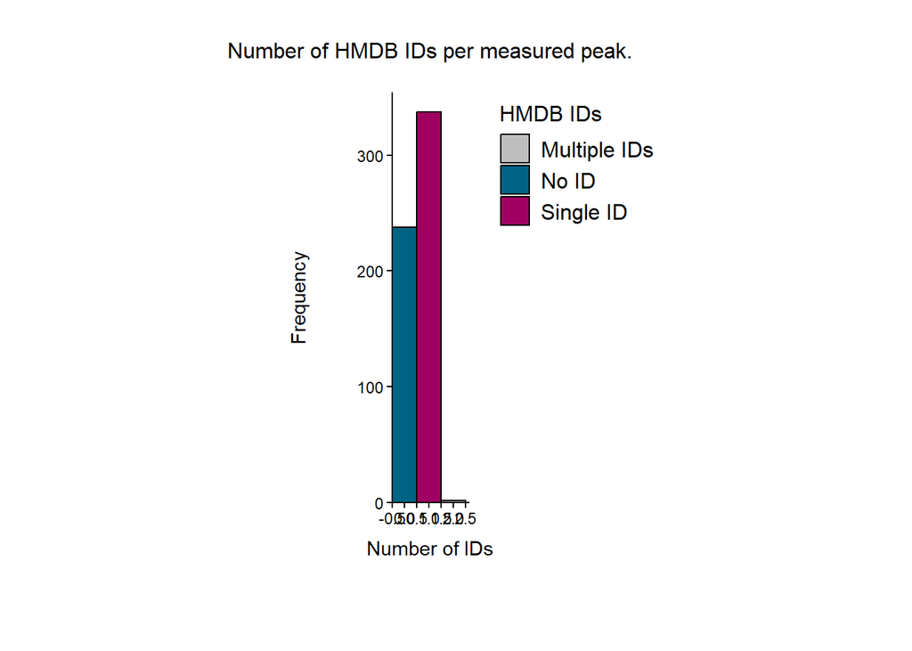

```r
Plot2_HMDB <- MetaProViz::count_id(MetaboliteIDs_cleaned,
                                   delimiter = id_separator,
                                   "HMDB",
                                   fill_colors = c(`No ID` = "#006384", `Single ID` = "#9F0162", `Multiple IDs` = "#BEBEBE"),
                                   path = "MetaProViz_Results/PK/PK_HMDB/Cleaned")
```

KEGG:

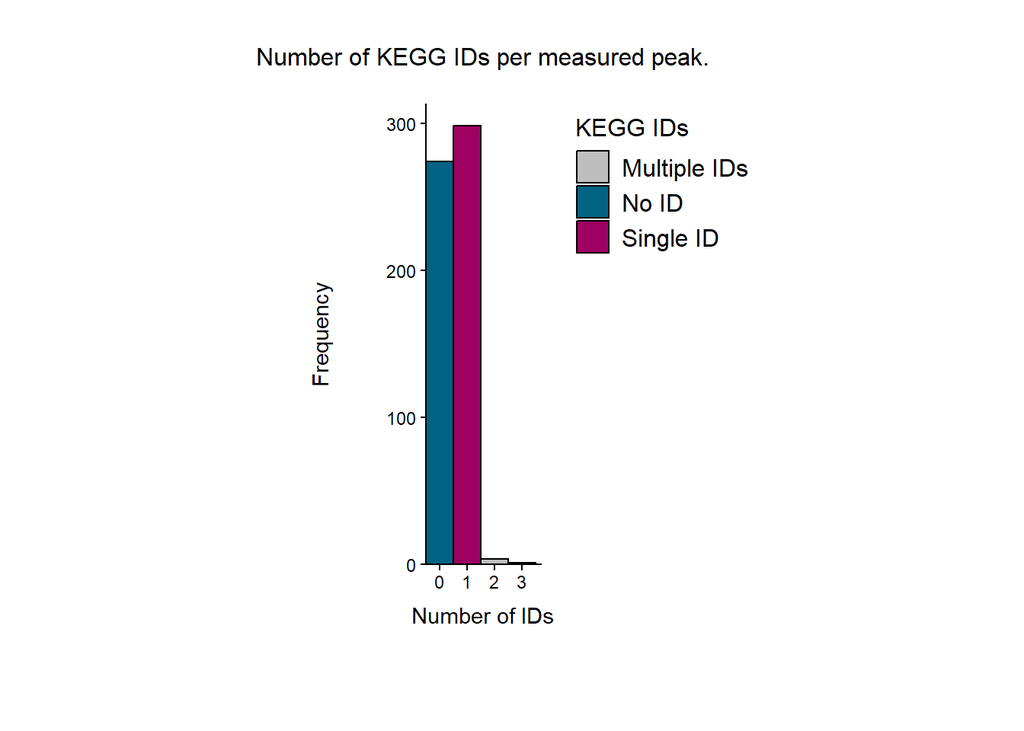

```r
Plot2_KEGG <- MetaProViz::count_id(MetaboliteIDs_cleaned,
                                   delimiter = id_separator,
                                   fill_colors = c(`No ID` = "#006384", `Single ID` = "#9F0162", `Multiple IDs` = "#BEBEBE"),
                                   "KEGG",
                                   path= "MetaProViz_Results/PK/PK_KEGG/Cleaned")
```

PubChem:

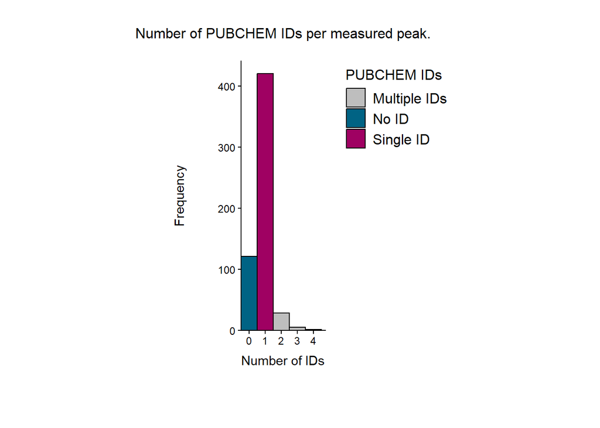

```r
Plot2_PubChem <- MetaProViz::count_id(MetaboliteIDs_cleaned,
                                   delimiter = id_separator,
                                   fill_colors = c(`No ID` = "#006384", `Single ID` = "#9F0162", `Multiple IDs` = "#BEBEBE"),
                                   "PUBCHEM",
                                   path= "MetaProViz_Results/PK/PK_PUBCHEM/Cleaned")
```

```r
# append the new "Cleaned" ID counts

## cleaned
id_count_df <- append_id_counts(id_count_df, Plot2_HMDB,    "HMDB_Cleaned")
id_count_df <- append_id_counts(id_count_df, Plot2_KEGG,    "KEGG_Cleaned")
id_count_df <- append_id_counts(id_count_df, Plot2_PubChem, "PUBCHEM_Cleaned")

## Calculate delta rows
delta_df <- calculate_id_deltas(id_count_df, "Original", "Cleaned")


## cleaned category dataframe
none_summary_df <- append_none_summary(none_summary_df, MetaboliteIDs_cleaned, "Cleaned")

## Calculate delta row
none_delta_df <- calculate_none_delta(none_summary_df, "Original", "Cleaned")
```

## Translate Cas to metabolite ID

Features with no HMDB, KEGG or PubChem ID

```r
# Extract features with No HMDB, KEGG or PubChem ID:
features_no_ids <- MetaboliteIDs_cleaned %>%
  dplyr::filter(
    (is.na(HMDB)    | trimws(HMDB) %in% c("", "NA")) &
    (is.na(KEGG)    | trimws(KEGG) %in% c("", "NA")) &
    (is.na(PUBCHEM) | trimws(PUBCHEM) %in% c("", "NA"))
  )

#Of those some may have a CAS number:
features_no_ids_with_cas <- features_no_ids %>%
  dplyr::filter(!(is.na(CAS) | trimws(CAS) %in% c("", "NA")))

#semicolon at the end needs to be removed

print(paste0("We have ", nrow(features_no_ids_with_cas), " features with CAS number but no other metabolite ID and ", nrow(features_no_ids)- nrow(features_no_ids_with_cas), " features with no CAS number and no other metabolite ID."))
```

```
#> [1] "We have 36 features with CAS number but no other metabolite ID and 40 features with no CAS number and no other metabolite ID."
```

There are some cases in which we have a CAS number, yet no HMDB, PubChem or KEGG ID. We can use the CAS number to check if we can find a metabolite ID for these features.

```r
features_ids_from_cas <- MetaProViz::translate_id(data = features_no_ids_with_cas,
                                                  metadata_info = list(InputID = "CAS", grouping_variable = "SUPER_PATHWAY"),
                                                  from = "cas",
                                                  to = c("hmdb", "kegg", "pubchem"),
                                                  path="MetaProViz_Results/PK/Translated")

# Keep only rows where at least one new ID was actually found
cas_ids_found <- features_ids_from_cas[["TranslatedDF"]] %>%
  dplyr::filter(
    !(is.na(hmdb)    | hmdb    == "") |
    !(is.na(kegg)    | kegg    == "") |
    !(is.na(pubchem) | pubchem == "")
  ) %>%
  # Replace the (empty) original ID columns with the translated ones
  dplyr::mutate(
    HMDB = normalize_id_cell(hmdb),
    KEGG = normalize_id_cell(kegg),
    PUBCHEM = normalize_id_cell(pubchem)
  ) %>%
  dplyr::select(-hmdb, -kegg, -pubchem)

# Merge back: update matching rows in MetaboliteIDs by COMP_ID
MetaboliteIDs_Translated <- MetaboliteIDs_cleaned %>%
  dplyr::rows_update(cas_ids_found, by = "COMP_ID")


## save as csv
write.csv2(
    MetaboliteIDs_Translated,
    "MetaProViz_Results/PK/Translated/MetaboliteIDs_Translated.csv"
)
```

We will repeat the `count_id` and `compare_pk` plot after every change to the number of metabolite IDs:

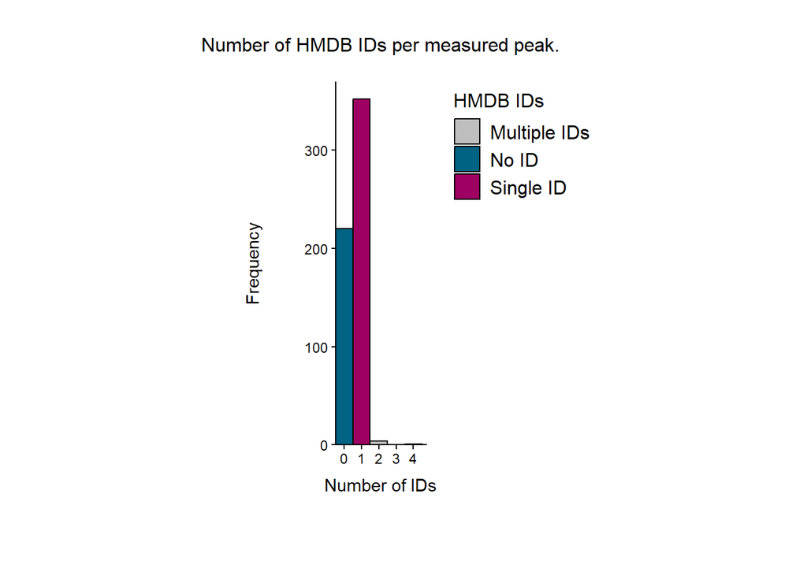

```r
ccRCC_CompareIDs_Translated <- MetaProViz::compare_pk(data = list(Biocft = MetaboliteIDs_Translated |> dplyr::rename("Class"="SUPER_PATHWAY")),
                                           name_col = "Metabolite",
                                           metadata_info = list(Biocft = c("KEGG", "HMDB", "PUBCHEM")),
                                           plot_name = "Overlap of ID types in ccRCC data",
                                           path= "MetaProViz_Results/PK/Translated")
Plot3_HMDB <- MetaProViz::count_id(MetaboliteIDs_Translated,
                                   delimiter = id_separator,
                                   "HMDB",
                                   fill_colors = c(`No ID` = "#006384", `Single ID` = "#9F0162", `Multiple IDs` = "#BEBEBE"),
                                   binwidth = 1,
                                   path = "MetaProViz_Results/PK/PK_HMDB/Translated")
```

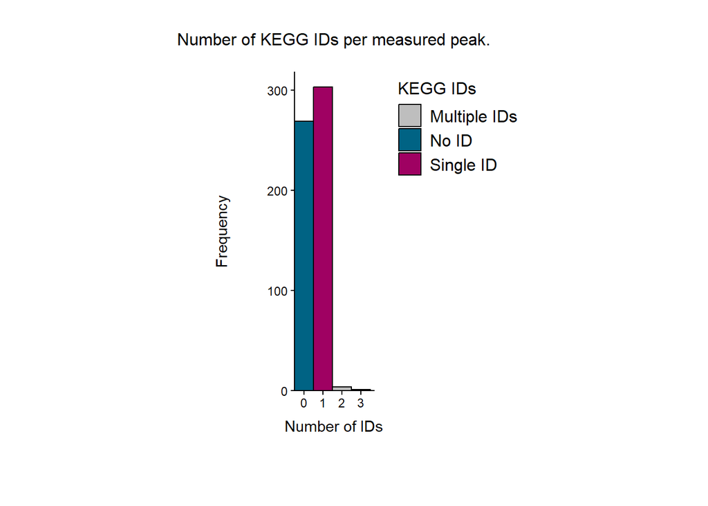

```r
Plot3_KEGG <- MetaProViz::count_id(MetaboliteIDs_Translated,
                                   delimiter = id_separator,
                                   fill_colors = c(`No ID` = "#006384", `Single ID` = "#9F0162", `Multiple IDs` = "#BEBEBE"),
                                   "KEGG",
                                   path= "MetaProViz_Results/PK/PK_KEGG/Translated")
```

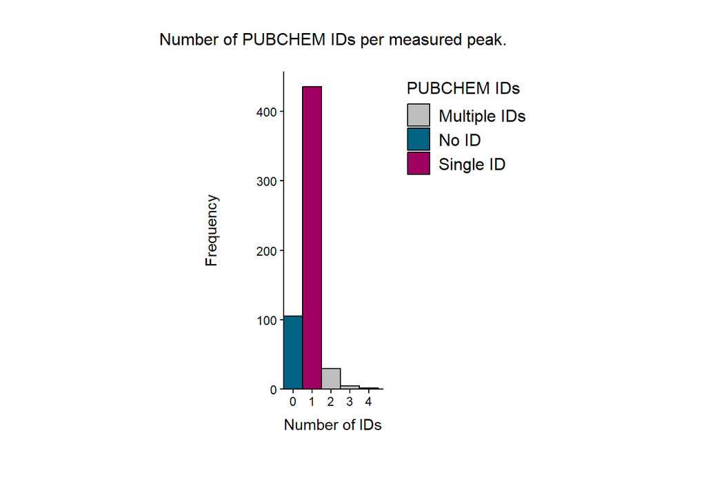

```r
Plot3_PubChem <- MetaProViz::count_id(MetaboliteIDs_Translated,
                                   delimiter = id_separator,
                                   fill_colors = c(`No ID` = "#006384", `Single ID` = "#9F0162", `Multiple IDs` = "#BEBEBE"),
                                   "PUBCHEM",
                                   path= "MetaProViz_Results/PK/PK_PUBCHEM/Translated")
```

```r
# append the new "Translated" ID counts

## translated
id_count_df <- append_id_counts(id_count_df, Plot3_HMDB,    "HMDB_Translated")
id_count_df <- append_id_counts(id_count_df, Plot3_KEGG,    "KEGG_Translated")
id_count_df <- append_id_counts(id_count_df, Plot3_PubChem, "PUBCHEM_Translated")

## Calculate delta rows
delta_df <- rbind(
  delta_df,
  calculate_id_deltas(id_count_df, "Original", "Translated"),
  calculate_id_deltas(id_count_df, "Cleaned", "Translated")
)


## cleaned category dataframe
none_summary_df <- append_none_summary(none_summary_df, MetaboliteIDs_Translated, "Translated")

## Calculate delta row
none_delta_df <- rbind(
  none_delta_df,
  calculate_none_delta(none_summary_df, "Original", "Translated"),
  calculate_none_delta(none_summary_df, "Cleaned", "Translated")
)
```

## Traverse ID

Next, we fill the gaps by expanding the metabolite identifiers across HMDB, KEGG and PubChem by building and traversing a metabolite ID graph (see methods for details). This fills the gaps by iteratively going through the cross-database mappings and collecting all connected IDs whilst additionally adding ChEBI IDs to the features.

```r
# Harmonize ID separators for traversal (function expects one delimiter)
Input_Traverse <- MetaboliteIDs_Translated %>%
  dplyr::mutate(
    HMDB = normalize_id_cell(HMDB),
    KEGG = normalize_id_cell(KEGG),
    PUBCHEM = normalize_id_cell(PUBCHEM)
  )

Results_Traverse <- MetaProViz::traverse_ids(
  data = Input_Traverse,
  id_types = c("HMDB", "KEGG", "CHEBI", "PUBCHEM"),
  delimiter = ",",
  path = "MetaProViz_Results/PK/Traverse"
)
## inspect results
traverse_ID_pair_compatibility <- Results_Traverse$ID_pair_compatibility
traverse_ID_edges <- Results_Traverse$ID_Edges_prior_knowledge
traverse_ID_ExpandedDF <- Results_Traverse$ExpandedDF

## save as csv
write.csv2(
    traverse_ID_ExpandedDF,
    "MetaProViz_Results/PK/Traverse/Traverse_IDs_Result___ExpandedDF.csv"
)
write.csv2(
    traverse_ID_edges,
    "MetaProViz_Results/PK/Traverse/Traverse_IDs_Result___ID_edges_prior_knowledge.csv"
)
write.csv2(
    traverse_ID_pair_compatibility,
    "MetaProViz_Results/PK/Traverse/Traverse_IDs_Result___ID_pair_compatibility.csv"
)
```

```r
# sanity checks after running traverse_ids()

# we manually curated id pair mismatches and sometimes kept mismatching ID pairs
# therefore, we dont the new ID QC (run within traverse_ids()) to only return
# "all_seed_ids_compatible" = TRUE
# now comes into play why we kept the "manual_curation" and "correction_tbl" columns


## how many features of the traverse_ID_ExpandedDF are all_seed_ids_compatible?
cat("Fully compatible features (PUBCHEM/KEGG/HMDB):", length(which(traverse_ID_ExpandedDF$all_seed_ids_compatible == TRUE)), "\n")
```

```
#> Fully compatible features (PUBCHEM/KEGG/HMDB): 508
```

```r
## how many features of the traverse_ID_ExpandedDF are NOT all_seed_ids_compatible?
cat("NOT fully compatible features (PUBCHEM/KEGG/HMDB):", length(which(traverse_ID_ExpandedDF$all_seed_ids_compatible == FALSE)), "\n")
```

```
#> NOT fully compatible features (PUBCHEM/KEGG/HMDB): 69
```

```r
## how many of these features with at least some incompatibility were NOT manually curated?
cat("NOT fully compatible features (PUBCHEM/KEGG/HMDB) WITHOUT a 'manual_curation' tag:", length(which(traverse_ID_ExpandedDF$all_seed_ids_compatible == FALSE & traverse_ID_ExpandedDF$manual_curation == FALSE)), "\n")
## Zero. This is great, since it means that all features with non-compatible IDs
# have been manually curated and therefore we trust the ID space, even though
# some are flagged as non-compatible
```

[output not shown]

```r
# Incorporate the newly added features into a new df "MetaboliteIDs_traverse"

MetaboliteIDs_traverse <-
    traverse_ID_ExpandedDF %>%
    mutate(
        PUBCHEM = {
            PUBCHEM_translated %>%
                normalize_id_cell() %>%
                gsub("CID", "", .)
        },
        KEGG = KEGG_translated %>% normalize_id_cell(),
        HMDB = HMDB_translated %>% normalize_id_cell(),
        CHEBI = CHEBI_translated %>% normalize_id_cell()
    ) %>%
    select(
        - all_seed_ids_compatible,
        - row_id,
        - HMDB_translated,
        - KEGG_translated,
        - CHEBI_translated,
        - PUBCHEM_translated,
        - n_seed_ids,
        - n_HMDB_translated,
        - n_KEGG_translated,
        - n_CHEBI_translated,
        - n_PUBCHEM_translated,
        - mapping_expanded,
        - ambiguous_seed,
        - large_mapping
    )

## save as csv
write.csv2(
    MetaboliteIDs_traverse,
    "MetaProViz_Results/PK/Traverse/MetaboliteIDs_traverse.csv"
)
```

We will repeat the `count_id` and `compare_pk` plot after every change to the number of metabolite IDs:

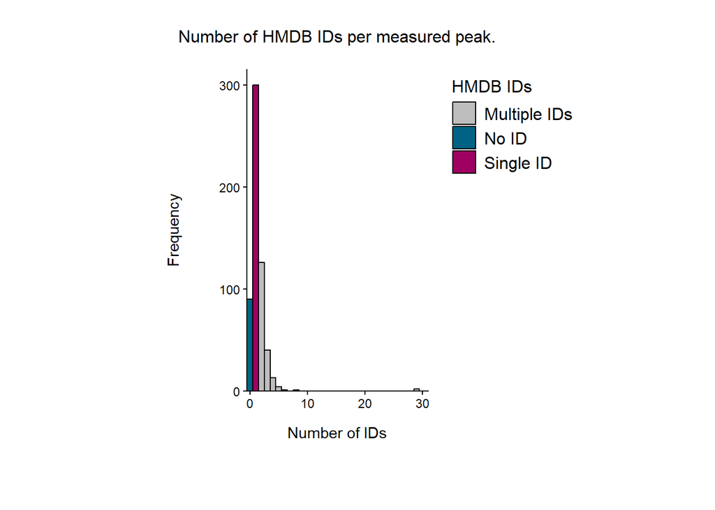

```r
ccRCC_CompareIDs_Traverse <- MetaProViz::compare_pk(data = list(Biocft = MetaboliteIDs_traverse |> dplyr::rename("Class"="SUPER_PATHWAY")),
                                           name_col = "Metabolite",
                                           metadata_info = list(Biocft = c("KEGG", "HMDB", "PUBCHEM", "CHEBI")),
                                           plot_name = "Overlap of ID types in ccRCC data",
                                           path= "MetaProViz_Results/PK/Traverse")
Plot4_HMDB <- MetaProViz::count_id(MetaboliteIDs_traverse,
                                   delimiter = id_separator,
                                   "HMDB",
                                   fill_colors = c(`No ID` = "#006384", `Single ID` = "#9F0162", `Multiple IDs` = "#BEBEBE"),
                                   binwidth = 1,
                                   path = "MetaProViz_Results/PK/PK_HMDB/Traverse")
```

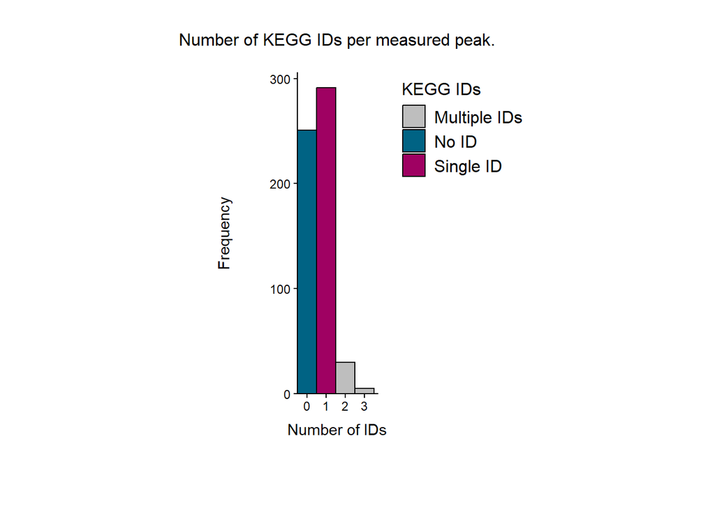

```r
Plot4_KEGG <- MetaProViz::count_id(MetaboliteIDs_traverse,
                                   delimiter = id_separator,
                                   fill_colors = c(`No ID` = "#006384", `Single ID` = "#9F0162", `Multiple IDs` = "#BEBEBE"),
                                   "KEGG",
                                   path= "MetaProViz_Results/PK/PK_KEGG/Traverse")
```

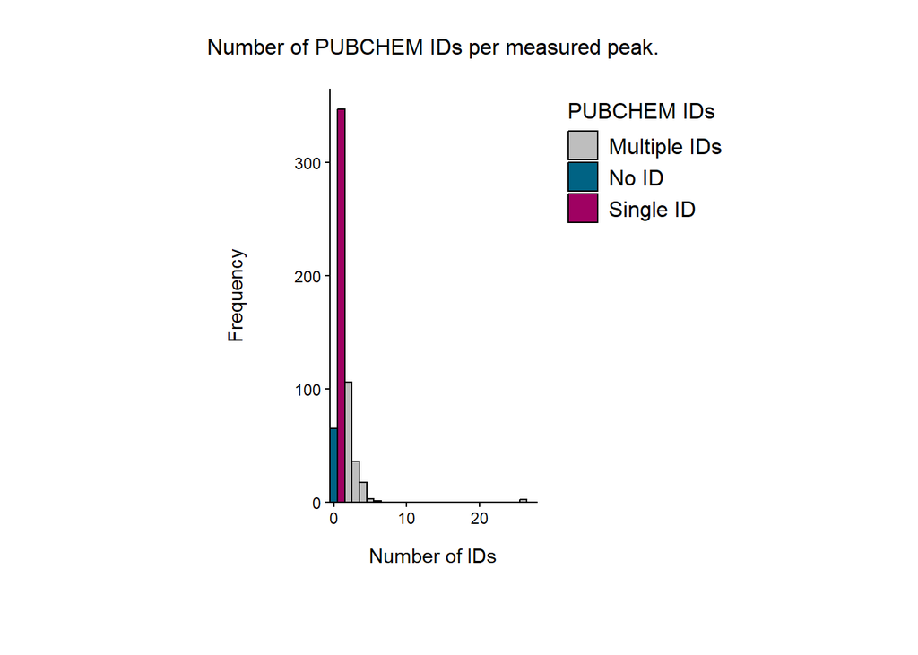

```r
Plot4_PubChem <- MetaProViz::count_id(MetaboliteIDs_traverse,
                                   delimiter = id_separator,
                                   fill_colors = c(`No ID` = "#006384", `Single ID` = "#9F0162", `Multiple IDs` = "#BEBEBE"),
                                   "PUBCHEM",
                                   path= "MetaProViz_Results/PK/PK_PUBCHEM/Traverse")
```

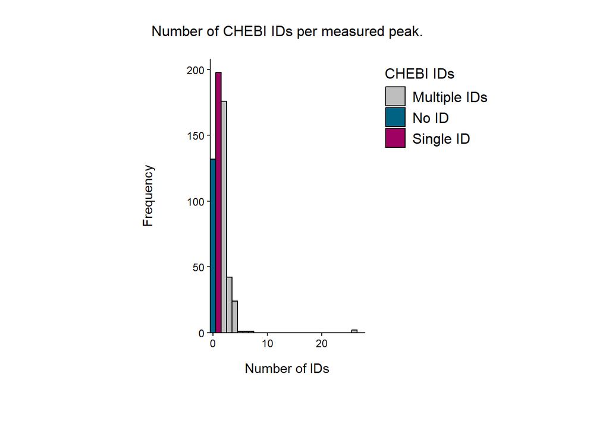

```r
Plot4_CHEBI <- MetaProViz::count_id(MetaboliteIDs_traverse,
                                   delimiter = id_separator,
                                   fill_colors = c(`No ID` = "#006384", `Single ID` = "#9F0162", `Multiple IDs` = "#BEBEBE"),
                                   "CHEBI",
                                   path= "MetaProViz_Results/PK/PK_CHEBI/Traverse")
```

We will start to compile a summary table that will include the number of IDs (1,2,n) after each step taken to increase the feature space. So now we will add the new IDs from Traverse ID

```r
## extend counting dataframe with traverse_id results

## traverse
id_count_df <- append_id_counts(id_count_df, Plot4_HMDB,    "HMDB_Traverse")
id_count_df <- append_id_counts(id_count_df, Plot4_KEGG,    "KEGG_Traverse")
id_count_df <- append_id_counts(id_count_df, Plot4_PubChem, "PUBCHEM_Traverse")
id_count_df <- append_id_counts(id_count_df, Plot4_CHEBI, "CHEBI_Traverse")


## Calculate delta rows
delta_df <- rbind(
  delta_df,
  calculate_id_deltas(id_count_df, "Original", "Traverse"),
  calculate_id_deltas(id_count_df, "Cleaned", "Traverse"),
  calculate_id_deltas(id_count_df, "Translated", "Traverse")
)


## cleaned category dataframe
none_summary_df <- append_none_summary(none_summary_df, MetaboliteIDs_traverse, "Traverse")

## Calculate delta row
none_delta_df <- rbind(
  none_delta_df,
  calculate_none_delta(none_summary_df, "Original", "Traverse"),
  calculate_none_delta(none_summary_df, "Cleaned", "Traverse"),
  calculate_none_delta(none_summary_df, "Translated", "Traverse")
)
```

## Eqivalent ID

```r
## prepare inputs for equivalent_id:
## make long format table from ID types, keep COMP_ID as grouping variable
## to join back together afterwards

## HMDB
Input_HMDB <- MetaboliteIDs_traverse %>%
    select(
        COMP_ID,
        HMDB
    ) %>%
    separate_rows(
        HMDB, sep = ","
    ) %>%
    mutate(
        HMDB = str_trim(HMDB)
    ) %>%
    filter(
        HMDB != ""
    )

## KEGG
Input_KEGG <- MetaboliteIDs_traverse %>%
    select(
        COMP_ID,
        KEGG
    ) %>%
    separate_rows(
        KEGG, sep = ","
    ) %>%
    mutate(
        KEGG = str_trim(KEGG)
    ) %>%
    filter(
        KEGG != ""
    )

## PUBCHEM
Input_PUBCHEM <- MetaboliteIDs_traverse %>%
    select(
        COMP_ID,
        PUBCHEM
    ) %>%
    separate_rows(
        PUBCHEM, sep = ","
    ) %>%
    mutate(
        PUBCHEM = str_trim(PUBCHEM)
    ) %>%
    filter(
        PUBCHEM != ""
    )

## CHEBI
Input_CHEBI <- MetaboliteIDs_traverse %>%
    select(
        COMP_ID,
        CHEBI
    ) %>%
    separate_rows(
        CHEBI, sep = ","
    ) %>%
    mutate(
        CHEBI = str_trim(CHEBI)
    ) %>%
    filter(
        CHEBI != ""
    ) %>%
    mutate(  ## remove "CHEBI:" prefix for equivalent_id
        CHEBI = gsub("^CHEBI:", "", CHEBI)
    )
```

```r
# before adding equivalent IDs, it is important to note, that the function
# equivalent_id internally drops duplicated IDs from the metadata_info["Input_ID"]

# in our case, we have some features which share the same HMDB ID, which was added
# through traverse_ids() and therefore we would drop this info

# one example is HMDB0001496 and C03594.
# Both these IDs point to a molecule called "7-alpha-hydroxycholesterol"
# There is also "7-beta-hydroxycholesterol" in the data and through traverse_ids(),
# this molecule also received the same IDs: MDB0001496 and C03594

# The only difference in these two molecules is stereochemistry, therefore it may
# be discussed whether these ID mappings actually do make sense or not.

# In any case, we are going to keep the IDs as they are, therefore we'll
# compute equivalent_id on a unique ID set and map the expanded IDs back via the original ID


## HMDB

distinct_HMDB <- Input_HMDB %>% distinct(HMDB, .keep_all = FALSE)

equivalent_id_res_HMDB <- MetaProViz::equivalent_id(data= distinct_HMDB,
                                                    metadata_info = c(InputID="HMDB"),
                                                    from = "hmdb",
                                                    path = "MetaProViz_Results/PK/PK_HMDB/EquivalentID")
```

```
#> chebi is used to find additional potential IDs for hmdb.
```

```r
## there is one HMDB (HMDB0031818) which is now duplicated after the equivalent_id function
equivalent_id_res_HMDB_clean <-
    equivalent_id_res_HMDB %>%
    group_by(HMDB) %>%
    summarise(
        across(
            c(PotentialAdditionalIDs, AllIDs), ~{
                ids <- strsplit(as.character(.x), ",\\s*")
                ids <- trimws(unlist(ids, use.names = FALSE))
                ids <- ids[!is.na(ids) & ids != "" & ids != "NA"]
                if (length(ids) == 0) NA_character_ else paste(unique(ids), collapse = ", ")
            }
        ),
        .groups = "drop"
    )

# now map the cleaned output from equivalent_id back to the COMP_ID
output_HMDB <- Input_HMDB %>%
    left_join(
        equivalent_id_res_HMDB_clean %>%
            select(
                HMDB,
                PotentialAdditionalIDs,
                AllIDs
            ),
        by = "HMDB"
      ) %>%
      group_by(COMP_ID) %>%
      summarise(
          HMDB = {
              ids <- unlist(strsplit(paste(AllIDs, collapse = ", "), ",\\s*"))
              ids <- trimws(ids)
              ids <- unique(ids[!is.na(ids) & ids != "" & ids != "NA"])
              if (length(ids) == 0) NA_character_ else paste(ids, collapse = ", ")
          },
          .groups = "drop"
      )


## KEGG

distinct_KEGG <- Input_KEGG %>% distinct(KEGG, .keep_all = FALSE)

equivalent_id_res_KEGG <- MetaProViz::equivalent_id(data= distinct_KEGG,
                                                    metadata_info = c(InputID="KEGG"),
                                                    from = "kegg",
                                                    path = "MetaProViz_Results/PK/PK_KEGG/EquivalentID")
```

```
#> chebi is used to find additional potential IDs for kegg.
```

```r
equivalent_id_res_KEGG_clean <-
    equivalent_id_res_KEGG %>%
    group_by(KEGG) %>%
    summarise(
        across(
            c(PotentialAdditionalIDs, AllIDs), ~{
                ids <- strsplit(as.character(.x), ",\\s*")
                ids <- trimws(unlist(ids, use.names = FALSE))
                ids <- ids[!is.na(ids) & ids != "" & ids != "NA"]
                if (length(ids) == 0) NA_character_ else paste(unique(ids), collapse = ", ")
            }
        ),
        .groups = "drop"
    )

# now map the cleaned output from equivalent_id back to the COMP_ID
output_KEGG <- Input_KEGG %>%
    left_join(
        equivalent_id_res_KEGG_clean %>%
            select(
                KEGG,
                PotentialAdditionalIDs,
                AllIDs
            ),
        by = "KEGG"
      ) %>%
      group_by(COMP_ID) %>%
      summarise(
          KEGG = {
              ids <- unlist(strsplit(paste(AllIDs, collapse = ", "), ",\\s*"))
              ids <- trimws(ids)
              ids <- unique(ids[!is.na(ids) & ids != "" & ids != "NA"])
              if (length(ids) == 0) NA_character_ else paste(ids, collapse = ", ")
          },
          .groups = "drop"
      )


## PUBCHEM

distinct_PUBCHEM <- Input_PUBCHEM %>% distinct(PUBCHEM, .keep_all = FALSE)

equivalent_id_res_PUBCHEM <- MetaProViz::equivalent_id(data= distinct_PUBCHEM,
                                                    metadata_info = c(InputID="PUBCHEM"),
                                                    from = "pubchem",
                                                    path = "MetaProViz_Results/PK/PK_PUBCHEM/EquivalentID")
```

```
#> chebi is used to find additional potential IDs for pubchem.
```

```r
equivalent_id_res_PUBCHEM_clean <-
    equivalent_id_res_PUBCHEM %>%
    group_by(PUBCHEM) %>%
    summarise(
        across(
            c(PotentialAdditionalIDs, AllIDs), ~{
                ids <- strsplit(as.character(.x), ",\\s*")
                ids <- trimws(unlist(ids, use.names = FALSE))
                ids <- ids[!is.na(ids) & ids != "" & ids != "NA"]
                if (length(ids) == 0) NA_character_ else paste(unique(ids), collapse = ", ")
            }
        ),
        .groups = "drop"
    )

# now map the cleaned output from equivalent_id back to the COMP_ID
output_PUBCHEM <- Input_PUBCHEM %>%
    left_join(
        equivalent_id_res_PUBCHEM_clean %>%
            select(
                PUBCHEM,
                PotentialAdditionalIDs,
                AllIDs
            ),
        by = "PUBCHEM"
      ) %>%
      group_by(COMP_ID) %>%
      summarise(
          PUBCHEM = {
              ids <- unlist(strsplit(paste(AllIDs, collapse = ", "), ",\\s*"))
              ids <- trimws(ids)
              ids <- unique(ids[!is.na(ids) & ids != "" & ids != "NA"])
              if (length(ids) == 0) NA_character_ else paste(ids, collapse = ", ")
          },
          .groups = "drop"
      )


## CHEBI

distinct_CHEBI <- Input_CHEBI %>% distinct(CHEBI, .keep_all = FALSE)

equivalent_id_res_CHEBI <- MetaProViz::equivalent_id(data= distinct_CHEBI,
                                                    metadata_info = c(InputID="CHEBI"),
                                                    from = "chebi",
                                                    path = "MetaProViz_Results/PK/PK_CHEBI/EquivalentID")
```

```
#> pubchem is used to find additional potential IDs for chebi.
```

```r
equivalent_id_res_CHEBI_clean <-
    equivalent_id_res_CHEBI %>%
    group_by(CHEBI) %>%
    summarise(
        across(
            c(PotentialAdditionalIDs, AllIDs), ~{
                ids <- strsplit(as.character(.x), ",\\s*")
                ids <- trimws(unlist(ids, use.names = FALSE))
                ids <- ids[!is.na(ids) & ids != "" & ids != "NA"]
                if (length(ids) == 0) NA_character_ else paste(unique(ids), collapse = ", ")
            }
        ),
        .groups = "drop"
    )

# now map the cleaned output from equivalent_id back to the COMP_ID
output_CHEBI <- Input_CHEBI %>%
    left_join(
        equivalent_id_res_CHEBI_clean %>%
            select(
                CHEBI,
                PotentialAdditionalIDs,
                AllIDs
            ),
        by = "CHEBI"
      ) %>%
      group_by(COMP_ID) %>%
      summarise(
          CHEBI = {
              ids <- unlist(strsplit(paste(AllIDs, collapse = ", "), ",\\s*"))
              ids <- trimws(ids)
              ids <- unique(ids[!is.na(ids) & ids != "" & ids != "NA"])
              if (length(ids) == 0) NA_character_ else paste(ids, collapse = ", ")
          },
          .groups = "drop"
      )




## IMPORTANT NOTE:

# in the function equivalent_id, there is a hard-coded part:
# OtherIDs <- merge(OtherIDs, EquivalentFeatures_Long, by.x = metadata_info[["InputID"]], by.y = "hmdb", ...
# where the merge happend explicitly on the "hmdb" column.

# if not provided, then there is an error
# BUT the function also works for KEGG input, since then this hard-coded block is not executed at all

# best way: fix it so the expression says:   by.y = from
# for now: only use equivalent_id on HMDB and KEGG


# CONTINUE

# now HMDB and KEGG IDs were expanded and we are going to join them back into a new
# df, MetaboliteIDs_add_eqivalent

MetaboliteIDs_addEquivalent <-
    MetaboliteIDs_traverse %>%
        select(
            -any_of(c("HMDB", "KEGG", "PUBCHEM", "CHEBI"))
        ) %>%
        left_join(
            output_HMDB, by = "COMP_ID"
        ) %>%
        left_join(
            output_KEGG, by = "COMP_ID"
        ) %>%
        left_join(
            output_PUBCHEM, by = "COMP_ID"
        ) %>%
        left_join(
            output_CHEBI, by = "COMP_ID"
        ) %>%
        relocate(PUBCHEM, KEGG, HMDB, CHEBI, .after = COMP_ID)


## save this table
write.csv2(
    MetaboliteIDs_addEquivalent,
    "MetaProViz_Results/PK/EquivalentID/MetaboliteIDs_addEquivalent.csv"
)
```

We will repeat the `count_id` and `compare_pk` plot after every change to the number of metabolite IDs:

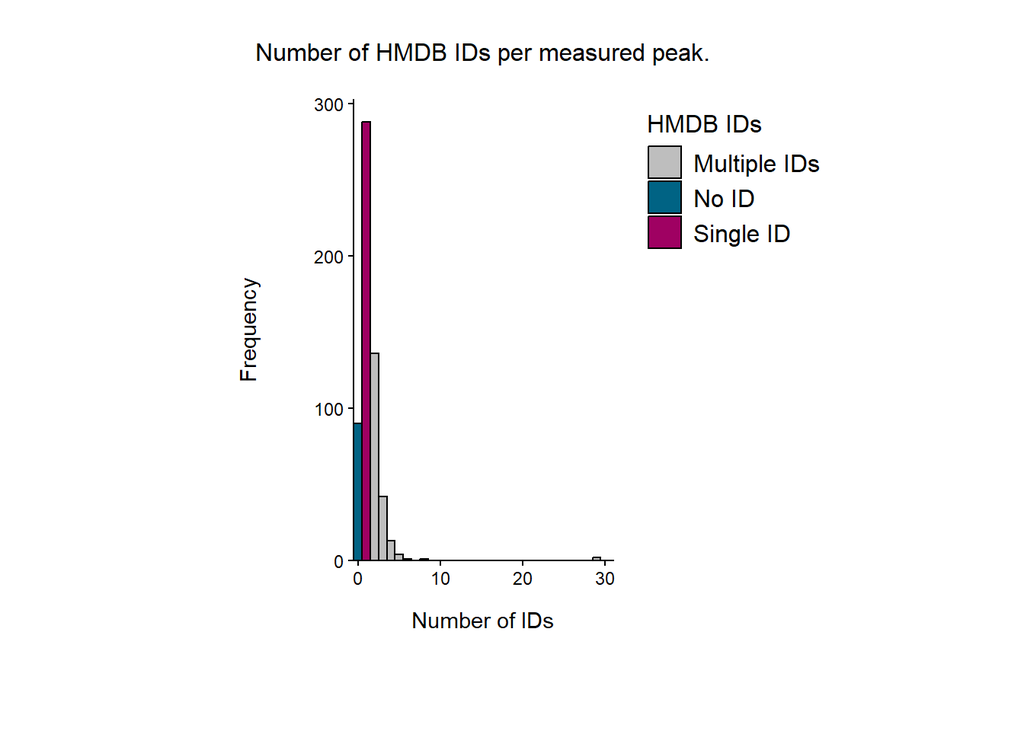

```r
ccRCC_CompareIDs_addEquivalent <- MetaProViz::compare_pk(data = list(Biocft = MetaboliteIDs_addEquivalent |> dplyr::rename("Class"="SUPER_PATHWAY")),
                                                         name_col = "Metabolite",
                                                         metadata_info = list(Biocft = c("KEGG", "HMDB", "PUBCHEM", "CHEBI")),
                                                         plot_name = "Overlap of ID types in ccRCC data",
                                                         path= "MetaProViz_Results/PK/EquivalentID")
Plot5_HMDB <- MetaProViz::count_id(MetaboliteIDs_addEquivalent,
                                   delimiter = id_separator,
                                   "HMDB",
                                   fill_colors = c(`No ID` = "#006384", `Single ID` = "#9F0162", `Multiple IDs` = "#BEBEBE"),
                                   binwidth = 1,
                                   path = "MetaProViz_Results/PK/PK_HMDB/EquivalentID")
```

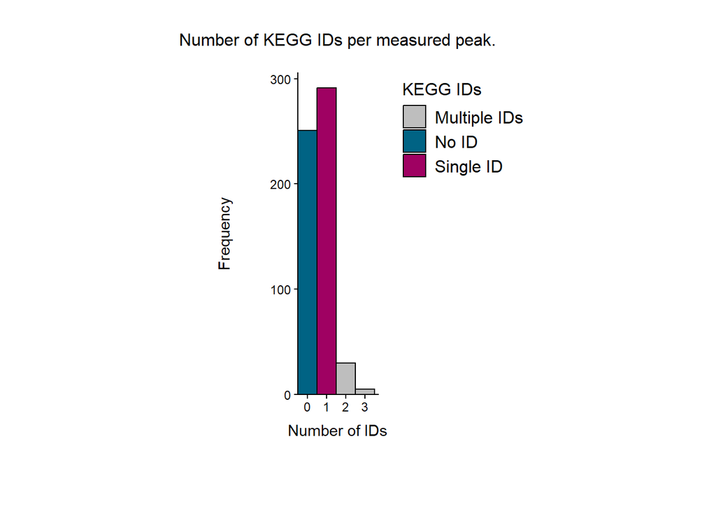

```r
Plot5_KEGG <- MetaProViz::count_id(MetaboliteIDs_addEquivalent,
                                   delimiter = id_separator,
                                   fill_colors = c(`No ID` = "#006384", `Single ID` = "#9F0162", `Multiple IDs` = "#BEBEBE"),
                                   "KEGG",
                                   path= "MetaProViz_Results/PK/PK_KEGG/EquivalentID")
```

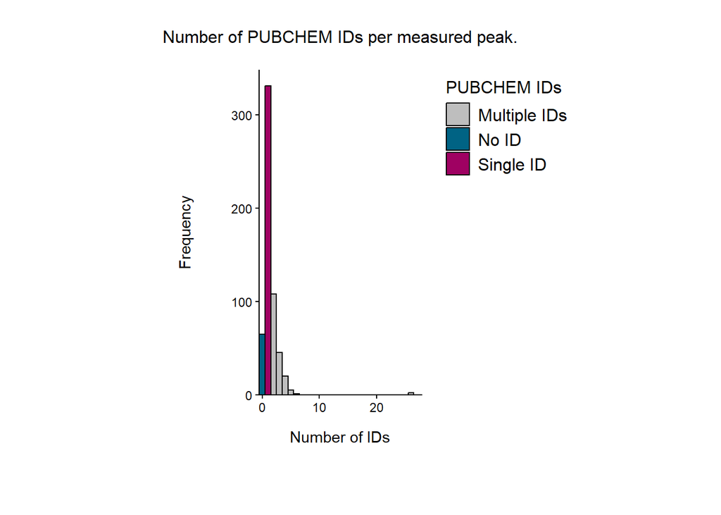

```r
Plot5_PubChem <- MetaProViz::count_id(MetaboliteIDs_addEquivalent,
                                   delimiter = id_separator,
                                   fill_colors = c(`No ID` = "#006384", `Single ID` = "#9F0162", `Multiple IDs` = "#BEBEBE"),
                                   "PUBCHEM",
                                   path= "MetaProViz_Results/PK/PK_PUBCHEM/EquivalentID")
```

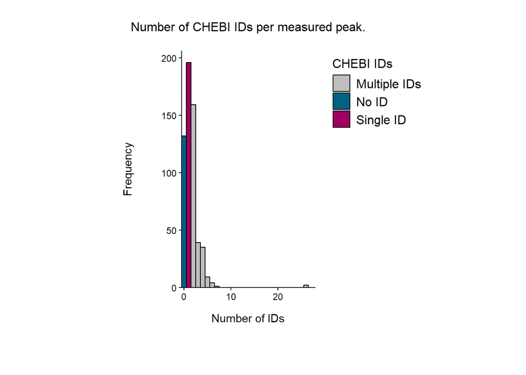

```r
Plot5_CHEBI <- MetaProViz::count_id(MetaboliteIDs_addEquivalent,
                                   delimiter = id_separator,
                                   fill_colors = c(`No ID` = "#006384", `Single ID` = "#9F0162", `Multiple IDs` = "#BEBEBE"),
                                   "CHEBI",
                                   path= "MetaProViz_Results/PK/PK_CHEBI/EquivalentID")
```

```r
## extend counting dataframe with traverse_id results

## traverse
id_count_df <- append_id_counts(id_count_df, Plot5_HMDB,    "HMDB_addEquivalent")
id_count_df <- append_id_counts(id_count_df, Plot5_KEGG,    "KEGG_addEquivalent")
id_count_df <- append_id_counts(id_count_df, Plot5_PubChem, "PUBCHEM_addEquivalent")
id_count_df <- append_id_counts(id_count_df, Plot5_CHEBI, "CHEBI_addEquivalent")


## Calculate delta rows
delta_df <- rbind(
  delta_df,
  calculate_id_deltas(id_count_df, "Original", "addEquivalent"),
  calculate_id_deltas(id_count_df, "Cleaned", "addEquivalent"),
  calculate_id_deltas(id_count_df, "Translated", "addEquivalent"),
  calculate_id_deltas(id_count_df, "Traverse", "addEquivalent")
)


## cleaned category dataframe
none_summary_df <- append_none_summary(none_summary_df, MetaboliteIDs_traverse, "addEquivalent")

## Calculate delta row
none_delta_df <- rbind(
  none_delta_df,
  calculate_none_delta(none_summary_df, "Original", "addEquivalent"),
  calculate_none_delta(none_summary_df, "Cleaned", "addEquivalent"),
  calculate_none_delta(none_summary_df, "Translated", "addEquivalent"),
  calculate_none_delta(none_summary_df, "Traverse", "addEquivalent")
)
```

```r
# save id summary tables

write.csv2(
    id_count_df,
    "MetaProViz_Results/PK/id_summary/id_count_df.csv"
)

write.csv2(
    delta_df,
    "MetaProViz_Results/PK/id_summary/delta_df.csv"
)

write.csv2(
    none_summary_df,
    "MetaProViz_Results/PK/id_summary/none_summary_df.csv"
)

write.csv2(
    none_delta_df,
    "MetaProViz_Results/PK/id_summary/none_delta_df.csv"
)
```

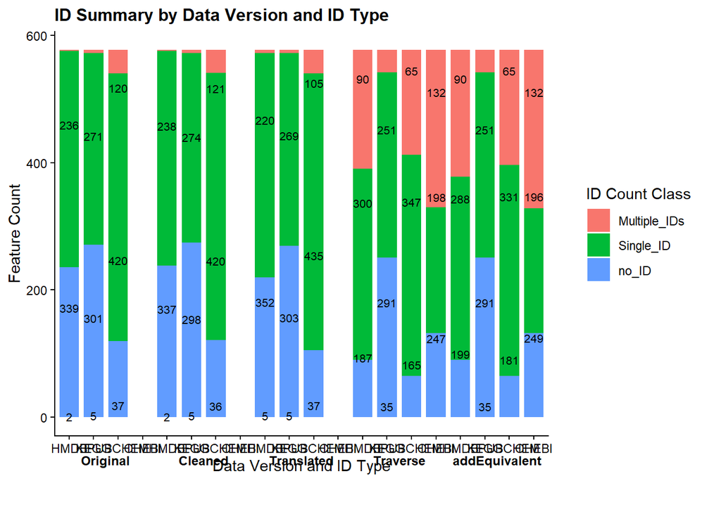

```r
## summary counting table including all deltas as bargraph

## save everything to:     MetaProViz_Results\PK\id_summary_plots
if (!dir.exists("MetaProViz_Results/PK/id_summary_plots")) {
  dir.create("MetaProViz_Results/PK/id_summary_plots", recursive = TRUE)
}

## ID summary plots
library(ggplot2)

id_types <- c("HMDB", "KEGG", "PUBCHEM", "CHEBI")
id_type_colors <- c(
  HMDB = "#bbcc33",
  KEGG = "#99ddff",
  PUBCHEM = "#feaf16",
  CHEBI = "#d03293"
)
data_versions <- c("Original", "Cleaned", "Translated", "Traverse", "addEquivalent")
theme_no_grid <- theme_bw() +
  theme(
    panel.grid.major = element_blank(),
    panel.grid.minor = element_blank()
  )
mpv_theme <- theme_classic(base_size = 11) +
  theme(
    plot.title = element_text(size = 12, face = "bold"),
    axis.text.x = element_text(angle = 90, hjust = 1),
    legend.position = "right",
    legend.box = "vertical",
    legend.box.margin = margin(10, 10, 10, 10)
  )
plot_theme <- theme_no_grid + mpv_theme

id_summary_plot_df <- id_count_df %>%
  mutate(
    id_type = sub("_.*$", "", row_name),
    data_version = sub("^[^_]+_", "", row_name)
  ) %>%
  filter(id_type %in% id_types, data_version %in% data_versions) %>%
  mutate(
    id_type = factor(id_type, levels = id_types),
    data_version = factor(data_version, levels = data_versions)
  ) %>%
  complete(
    id_type,
    data_version,
    fill = list(no_ID = 0L, Single_ID = 0L, Multiple_IDs = 0L, Total_IDs = 0L)
  )

version_levels <- unlist(lapply(data_versions, function(v) paste(v, id_types, sep = " | ")))
type_levels <- unlist(lapply(id_types, function(t) paste(t, data_versions, sep = " | ")))

compact_bar_labels <- function(x) sub("^.*\\|\\s*", "", x)

version_group_labels <- tibble(
  data_version = data_versions,
  x = ((seq_along(data_versions) - 1) * length(id_types)) + (length(id_types) + 1) / 2
)

type_group_labels <- tibble(
  id_type = id_types,
  x = ((seq_along(id_types) - 1) * length(data_versions)) + (length(data_versions) + 1) / 2
)

version_group_annotation <- geom_text(
  data = version_group_labels,
  aes(x = x, y = -Inf, label = data_version),
  inherit.aes = FALSE,
  vjust = 3.0,
  fontface = "bold",
  size = 3.2
)

type_group_annotation <- geom_text(
  data = type_group_labels,
  aes(x = x, y = -Inf, label = id_type),
  inherit.aes = FALSE,
  vjust = 3.0,
  fontface = "bold",
  size = 3.2
)

bar_plot_theme <- plot_theme +
  theme(
    axis.text.x = element_text(angle = 0, hjust = 0.5),
    plot.margin = margin(5.5, 5.5, 28, 5.5)
  )

id_summary_plot_df <- id_summary_plot_df %>%
  mutate(
    group_by_version = factor(paste(as.character(data_version), as.character(id_type), sep = " | "), levels = version_levels),
    group_by_type = factor(paste(as.character(id_type), as.character(data_version), sep = " | "), levels = type_levels)
  )

stacked_long_version <- id_summary_plot_df %>%
  pivot_longer(
    cols = c(no_ID, Single_ID, Multiple_IDs),
    names_to = "id_bucket",
    values_to = "count"
  ) %>%
  mutate(id_bucket = factor(id_bucket, levels = c("Multiple_IDs", "Single_ID", "no_ID"))) %>%
  group_by(group_by_version) %>%
  arrange(id_bucket, .by_group = TRUE) %>%
  mutate(label_y = cumsum(count) - count / 2) %>%
  ungroup()

stacked_long_type <- id_summary_plot_df %>%
  pivot_longer(
    cols = c(no_ID, Single_ID, Multiple_IDs),
    names_to = "id_bucket",
    values_to = "count"
  ) %>%
  mutate(id_bucket = factor(id_bucket, levels = c("Multiple_IDs", "Single_ID", "no_ID"))) %>%
  group_by(group_by_type) %>%
  arrange(id_bucket, .by_group = TRUE) %>%
  mutate(label_y = cumsum(count) - count / 2) %>%
  ungroup()

p_id_stacked_by_version <- ggplot(stacked_long_version, aes(x = group_by_version, y = count, fill = id_bucket)) +
  geom_col(width = 0.8) +
  geom_text(
    aes(y = label_y, label = ifelse(count == 0, "", count)),
    color = "black",
    size = 2.8
  ) +
  scale_x_discrete(drop = FALSE, labels = compact_bar_labels) +
  labs(
    title = "ID Summary by Data Version and ID Type",
    x = "Data Version and ID Type",
    y = "Feature Count",
    fill = "ID Count Class"
  ) +
  version_group_annotation +
  coord_cartesian(clip = "off") +
  bar_plot_theme

p_total_ids_by_version <- ggplot(id_summary_plot_df, aes(x = group_by_version, y = Total_IDs, fill = id_type)) +
  geom_col(width = 0.8, show.legend = FALSE) +
  geom_text(
    aes(y = pmax(Total_IDs - 5, 0), label = ifelse(Total_IDs == 0, "", Total_IDs)),
    color = "black",
    size = 2.8,
    fontface = "bold"
  ) +
  scale_fill_manual(values = id_type_colors) +
  scale_x_discrete(drop = FALSE, labels = compact_bar_labels) +
  labs(
    title = "Total IDs by Data Version and ID Type",
    x = "Data Version and ID Type",
    y = "Total_IDs"
  ) +
  version_group_annotation +
  coord_cartesian(clip = "off") +
  bar_plot_theme

p_id_stacked_by_type <- ggplot(stacked_long_type, aes(x = group_by_type, y = count, fill = id_bucket)) +
  geom_col(width = 0.8) +
  geom_text(
    aes(y = label_y, label = ifelse(count == 0, "", count)),
    color = "black",
    size = 2.8
  ) +
  scale_x_discrete(drop = FALSE, labels = compact_bar_labels) +
  labs(
    title = "ID Summary by ID Type and Data Version",
    x = "ID Type and Data Version",
    y = "Feature Count",
    fill = "ID Count Class"
  ) +
  type_group_annotation +
  coord_cartesian(clip = "off") +
  bar_plot_theme

p_total_ids_by_type <- ggplot(id_summary_plot_df, aes(x = group_by_type, y = Total_IDs, fill = id_type)) +
  geom_col(width = 0.8, show.legend = FALSE) +
  geom_text(
    aes(y = pmax(Total_IDs - 5, 0), label = ifelse(Total_IDs == 0, "", Total_IDs)),
    color = "black",
    size = 2.8,
    fontface = "bold"
  ) +
  scale_fill_manual(values = id_type_colors) +
  scale_x_discrete(drop = FALSE, labels = compact_bar_labels) +
  labs(
    title = "Total IDs by ID Type and Data Version",
    x = "ID Type and Data Version",
    y = "Total_IDs"
  ) +
  type_group_annotation +
  coord_cartesian(clip = "off") +
  bar_plot_theme

print(p_id_stacked_by_version)
```

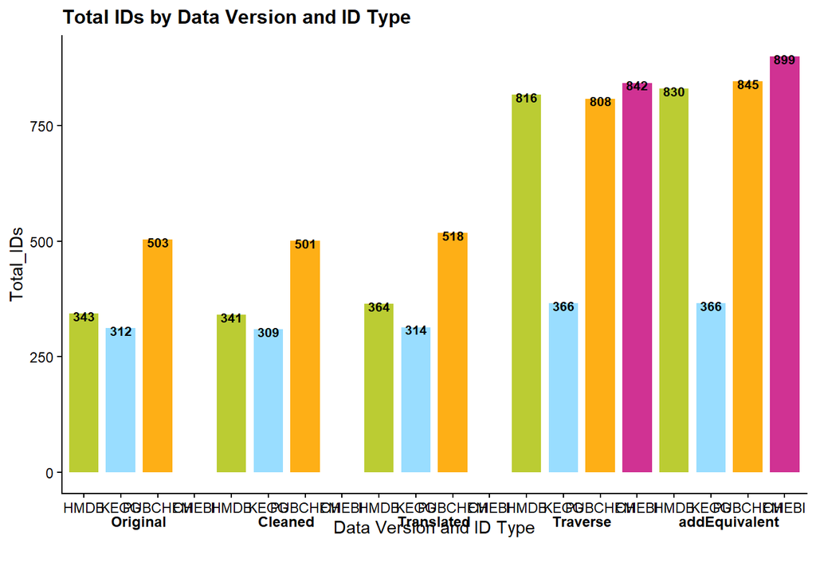

```r
print(p_total_ids_by_version)
```

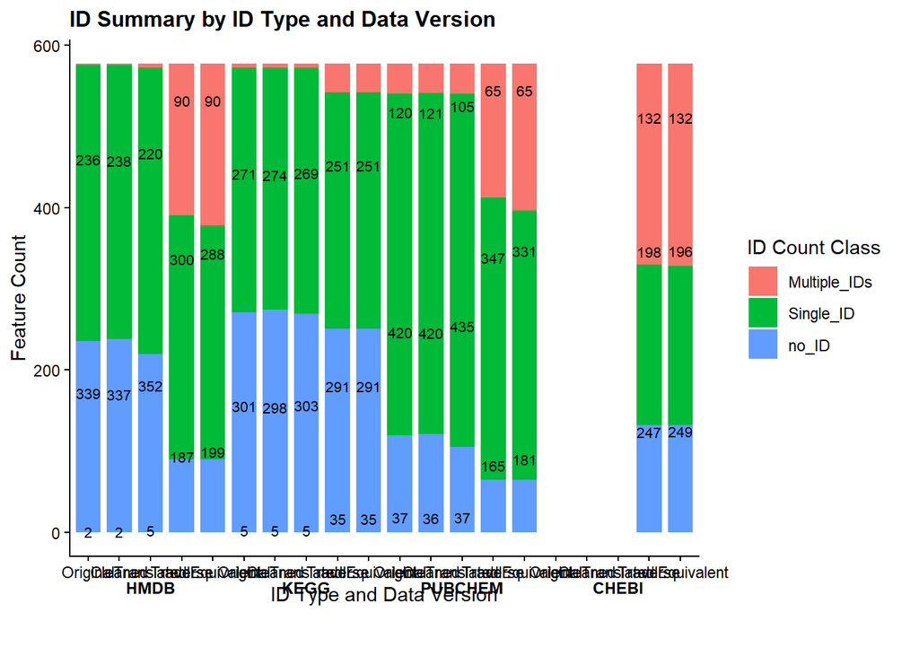

```r
print(p_id_stacked_by_type)
```

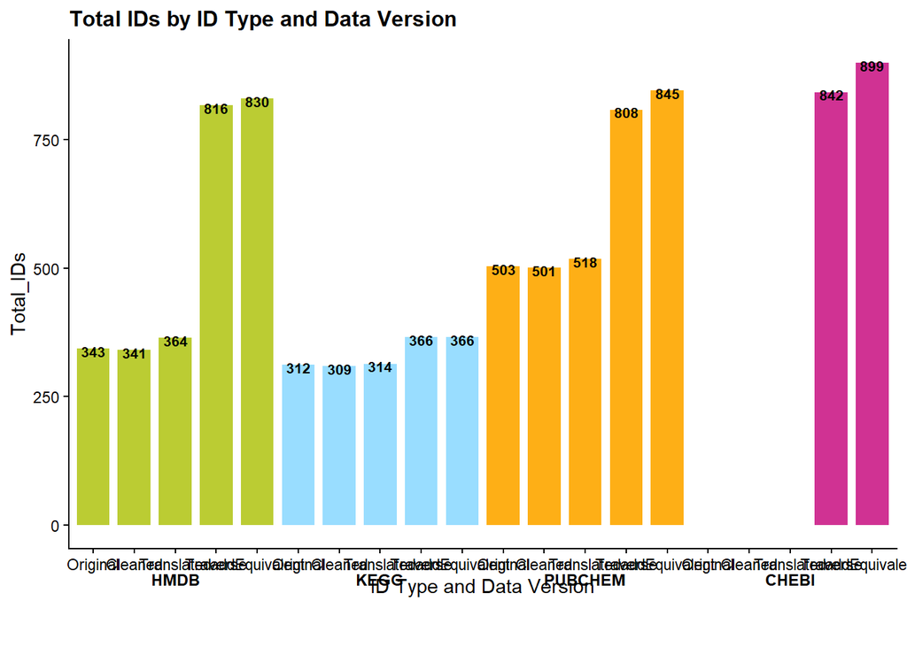

```r
print(p_total_ids_by_type)
```

[figure not shown]

```r
ggsave(
  filename = "MetaProViz_Results/PK/id_summary_plots/id_summary_stacked_by_data_version.png",
  plot = p_id_stacked_by_version,
  width = 16,
  height = 8,
  dpi = 300
)

ggsave(
  filename = "MetaProViz_Results/PK/id_summary_plots/id_summary_stacked_by_data_version.svg",
  plot = p_id_stacked_by_version,
  width = 16,
  height = 8
)

ggsave(
  filename = "MetaProViz_Results/PK/id_summary_plots/id_summary_total_ids_by_data_version.png",
  plot = p_total_ids_by_version,
  width = 16,
  height = 8,
  dpi = 300
)

ggsave(
  filename = "MetaProViz_Results/PK/id_summary_plots/id_summary_total_ids_by_data_version.svg",
  plot = p_total_ids_by_version,
  width = 16,
  height = 8
)

ggsave(
  filename = "MetaProViz_Results/PK/id_summary_plots/id_summary_stacked_by_id_type.png",
  plot = p_id_stacked_by_type,
  width = 16,
  height = 8,
  dpi = 300
)

ggsave(
  filename = "MetaProViz_Results/PK/id_summary_plots/id_summary_stacked_by_id_type.svg",
  plot = p_id_stacked_by_type,
  width = 16,
  height = 8
)

ggsave(
  filename = "MetaProViz_Results/PK/id_summary_plots/id_summary_total_ids_by_id_type.png",
  plot = p_total_ids_by_type,
  width = 16,
  height = 8,
  dpi = 300
)

ggsave(
  filename = "MetaProViz_Results/PK/id_summary_plots/id_summary_total_ids_by_id_type.svg",
  plot = p_total_ids_by_type,
  width = 16,
  height = 8
)







## ID summary plots with delta annotations (delta vs Original)

id_summary_with_delta_df <- id_summary_plot_df %>%
  group_by(id_type) %>%
  arrange(data_version, .by_group = TRUE) %>%
  mutate(
    delta_no_ID = no_ID - lag(no_ID, default = first(no_ID)),
    delta_Single_ID = Single_ID - lag(Single_ID, default = first(Single_ID)),
    delta_Multiple_IDs = Multiple_IDs - lag(Multiple_IDs, default = first(Multiple_IDs)),
    delta_Total_IDs = Total_IDs - lag(Total_IDs, default = first(Total_IDs))
  ) %>%
  ungroup()

stacked_long_version_delta <- id_summary_with_delta_df %>%
  pivot_longer(
    cols = c(no_ID, Single_ID, Multiple_IDs),
    names_to = "id_bucket",
    values_to = "count"
  ) %>%
  mutate(
    id_bucket = factor(id_bucket, levels = c("Multiple_IDs", "Single_ID", "no_ID")),
    delta_value = case_when(
      id_bucket == "no_ID" ~ delta_no_ID,
      id_bucket == "Single_ID" ~ delta_Single_ID,
      id_bucket == "Multiple_IDs" ~ delta_Multiple_IDs
    )
  ) %>%
  group_by(group_by_version) %>%
  arrange(id_bucket, .by_group = TRUE) %>%
  mutate(label_y = cumsum(count) - count / 2) %>%
  ungroup()

stacked_long_type_delta <- id_summary_with_delta_df %>%
  pivot_longer(
    cols = c(no_ID, Single_ID, Multiple_IDs),
    names_to = "id_bucket",
    values_to = "count"
  ) %>%
  mutate(
    id_bucket = factor(id_bucket, levels = c("Multiple_IDs", "Single_ID", "no_ID")),
    delta_value = case_when(
      id_bucket == "no_ID" ~ delta_no_ID,
      id_bucket == "Single_ID" ~ delta_Single_ID,
      id_bucket == "Multiple_IDs" ~ delta_Multiple_IDs
    )
  ) %>%
  group_by(group_by_type) %>%
  arrange(id_bucket, .by_group = TRUE) %>%
  mutate(label_y = cumsum(count) - count / 2) %>%
  ungroup()

p_id_stacked_by_version_with_delta <- ggplot(stacked_long_version_delta, aes(x = group_by_version, y = count, fill = id_bucket)) +
  geom_col(width = 0.8) +
  geom_text(
    aes(
      y = label_y,
      label = ifelse(count == 0 & delta_value == 0, "", paste0(count, "\nΔ", sprintf("%+d", delta_value)))
    ),
    color = "black",
    size = 2.5,
    lineheight = 0.9
  ) +
  scale_x_discrete(drop = FALSE, labels = compact_bar_labels) +
  labs(
    title = "ID Summary by Data Version and ID Type (with Δ vs Original)",
    x = "Data Version and ID Type",
    y = "Feature Count",
    fill = "ID Count Class"
  ) +
  version_group_annotation +
  coord_cartesian(clip = "off") +
  bar_plot_theme

p_total_ids_by_version_with_delta <- ggplot(id_summary_with_delta_df, aes(x = group_by_version, y = Total_IDs, fill = id_type)) +
  geom_col(width = 0.8, show.legend = FALSE) +
  geom_text(
    aes(
      y = pmax(Total_IDs - 8, 0),
      label = ifelse(Total_IDs == 0 & delta_Total_IDs == 0, "", paste0(Total_IDs, "\nΔ", sprintf("%+d", delta_Total_IDs)))
    ),
    color = "black",
    size = 2.6,
    fontface = "bold",
    lineheight = 0.9
  ) +
  scale_fill_manual(values = id_type_colors) +
  scale_x_discrete(drop = FALSE, labels = compact_bar_labels) +
  labs(
    title = "Total IDs by Data Version and ID Type (with Δ vs Original)",
    x = "Data Version and ID Type",
    y = "Total_IDs"
  ) +
  version_group_annotation +
  coord_cartesian(clip = "off") +
  bar_plot_theme

p_id_stacked_by_type_with_delta <- ggplot(stacked_long_type_delta, aes(x = group_by_type, y = count, fill = id_bucket)) +
  geom_col(width = 0.8) +
  geom_text(
    aes(
      y = label_y,
      label = ifelse(count == 0 & delta_value == 0, "", paste0(count, "\nΔ", sprintf("%+d", delta_value)))
    ),
    color = "black",
    size = 2.5,
    lineheight = 0.9
  ) +
  scale_x_discrete(drop = FALSE, labels = compact_bar_labels) +
  labs(
    title = "ID Summary by ID Type and Data Version (with Δ vs Original)",
    x = "ID Type and Data Version",
    y = "Feature Count",
    fill = "ID Count Class"
  ) +
  type_group_annotation +
  coord_cartesian(clip = "off") +
  bar_plot_theme

p_total_ids_by_type_with_delta <- ggplot(id_summary_with_delta_df, aes(x = group_by_type, y = Total_IDs, fill = id_type)) +
  geom_col(width = 0.8, show.legend = FALSE) +
  geom_text(
    aes(
      y = pmax(Total_IDs - 8, 0),
      label = ifelse(Total_IDs == 0 & delta_Total_IDs == 0, "", paste0(Total_IDs, "\nΔ", sprintf("%+d", delta_Total_IDs)))
    ),
    color = "black",
    size = 2.6,
    fontface = "bold",
    lineheight = 0.9
  ) +
  scale_fill_manual(values = id_type_colors) +
  scale_x_discrete(drop = FALSE, labels = compact_bar_labels) +
  labs(
    title = "Total IDs by ID Type and Data Version (with Δ vs Original)",
    x = "ID Type and Data Version",
    y = "Total_IDs"
  ) +
  type_group_annotation +
  coord_cartesian(clip = "off") +
  bar_plot_theme

print(p_id_stacked_by_version_with_delta)
```

[figure not shown]

```r
print(p_total_ids_by_version_with_delta)
```

[figure not shown]

```r
print(p_id_stacked_by_type_with_delta)
```

[figure not shown]

```r
print(p_total_ids_by_type_with_delta)
```

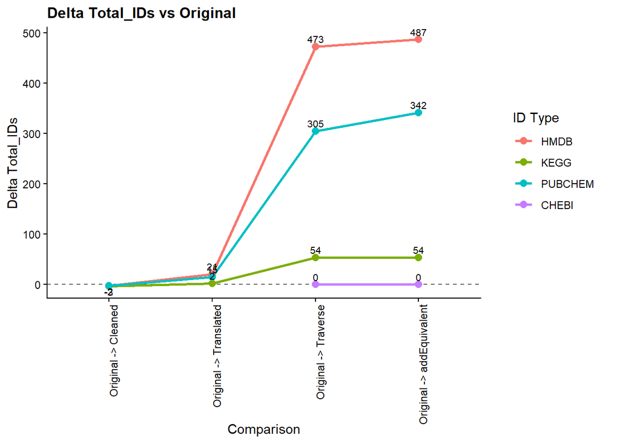

```r
ggsave(
  filename = "MetaProViz_Results/PK/id_summary_plots/id_summary_stacked_by_data_version_with_delta.png",
  plot = p_id_stacked_by_version_with_delta,
  width = 16,
  height = 8,
  dpi = 300
)

ggsave(
  filename = "MetaProViz_Results/PK/id_summary_plots/id_summary_stacked_by_data_version_with_delta.svg",
  plot = p_id_stacked_by_version_with_delta,
  width = 16,
  height = 8
)

ggsave(
  filename = "MetaProViz_Results/PK/id_summary_plots/id_summary_total_ids_by_data_version_with_delta.png",
  plot = p_total_ids_by_version_with_delta,
  width = 16,
  height = 8,
  dpi = 300
)

ggsave(
  filename = "MetaProViz_Results/PK/id_summary_plots/id_summary_total_ids_by_data_version_with_delta.svg",
  plot = p_total_ids_by_version_with_delta,
  width = 16,
  height = 8
)

ggsave(
  filename = "MetaProViz_Results/PK/id_summary_plots/id_summary_stacked_by_id_type_with_delta.png",
  plot = p_id_stacked_by_type_with_delta,
  width = 16,
  height = 8,
  dpi = 300
)

ggsave(
  filename = "MetaProViz_Results/PK/id_summary_plots/id_summary_stacked_by_id_type_with_delta.svg",
  plot = p_id_stacked_by_type_with_delta,
  width = 16,
  height = 8
)

ggsave(
  filename = "MetaProViz_Results/PK/id_summary_plots/id_summary_total_ids_by_id_type_with_delta.png",
  plot = p_total_ids_by_type_with_delta,
  width = 16,
  height = 8,
  dpi = 300
)

ggsave(
  filename = "MetaProViz_Results/PK/id_summary_plots/id_summary_total_ids_by_id_type_with_delta.svg",
  plot = p_total_ids_by_type_with_delta,
  width = 16,
  height = 8
)
## delta_df visualizations (baseline = Original)

baseline_steps <- tibble::tribble(
  ~from_version, ~to_version, ~step_label,
  "Original", "Cleaned", "Original -> Cleaned",
  "Original", "Translated", "Original -> Translated",
  "Original", "Traverse", "Original -> Traverse",
  "Original", "addEquivalent", "Original -> addEquivalent"
)

delta_plot_df <- delta_df %>%
  mutate(parts = stringr::str_split(row_name, "_", simplify = TRUE)) %>%
  mutate(
    id_type = parts[, 2],
    from_version = parts[, 3],
    to_id_type = parts[, 4],
    to_version = parts[, 5]
  ) %>%
  select(-parts) %>%
  filter(
    id_type %in% id_types,
    from_version %in% data_versions,
    to_version %in% data_versions
  ) %>%
  left_join(baseline_steps, by = c("from_version", "to_version")) %>%
  filter(!is.na(step_label)) %>%
  mutate(
    id_type = factor(id_type, levels = id_types),
    step_label = factor(step_label, levels = baseline_steps$step_label)
  ) %>%
  mutate(across(c(no_ID, Single_ID, Multiple_IDs, Total_IDs), ~ tidyr::replace_na(., 0)))

## Plot 1: Total_IDs deltas vs Original (line plot)
delta_total_df <- delta_plot_df %>%
  filter(!is.na(Total_IDs))

p_delta_total_vs_original <- ggplot(delta_total_df, aes(x = step_label, y = Total_IDs, color = id_type, group = id_type)) +
  geom_hline(yintercept = 0, linetype = "dashed", color = "grey40") +
  geom_line(linewidth = 0.9) +
  geom_point(size = 2.4) +
  geom_text(
    aes(label = Total_IDs),
    vjust = ifelse(delta_total_df$Total_IDs >= 0, -0.55, 1.25),
    size = 2.8,
    color = "black"
  ) +
  labs(
    title = "Delta Total_IDs vs Original",
    x = "Comparison",
    y = "Delta Total_IDs",
    color = "ID Type"
  ) +
  plot_theme

## Plot 2: no_ID / Single_ID / Multiple_IDs deltas vs Original (line plot)
delta_comp_long <- delta_plot_df %>%
  select(id_type, step_label, no_ID, Single_ID, Multiple_IDs) %>%
  pivot_longer(
    cols = c(no_ID, Single_ID, Multiple_IDs),
    names_to = "metric",
    values_to = "delta"
  ) %>%
  filter(!is.na(delta)) %>%
  mutate(metric = factor(metric, levels = c("no_ID", "Single_ID", "Multiple_IDs")))

p_delta_comp_vs_original <- ggplot(delta_comp_long, aes(x = step_label, y = delta, color = metric, group = metric)) +
  geom_hline(yintercept = 0, linetype = "dashed", color = "grey40") +
  geom_line(linewidth = 0.8) +
  geom_point(size = 2) +
  geom_text(
    aes(label = ifelse(delta == 0, "", delta)),
    vjust = ifelse(delta_comp_long$delta >= 0, -0.45, 1.15),
    size = 2.3,
    color = "black"
  ) +
  facet_wrap(~ id_type, ncol = 2) +
  labs(
    title = "Delta Composition vs Original",
    x = "Comparison",
    y = "Delta Count",
    color = "Metric"
  ) +
  plot_theme

print(p_delta_total_vs_original)
```

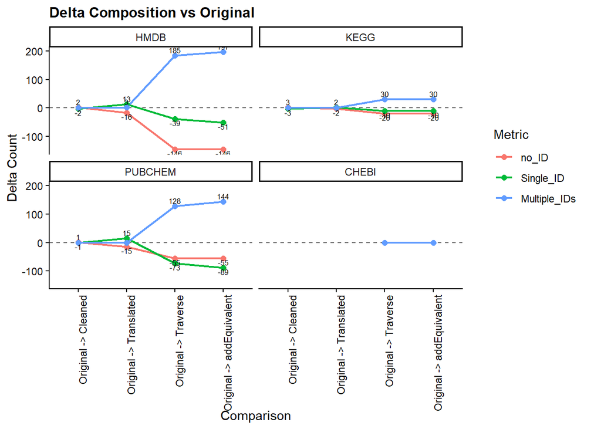

```r
print(p_delta_comp_vs_original)
```

```r
ggsave(
  filename = "MetaProViz_Results/PK/id_summary_plots/delta_total_vs_original.png",
  plot = p_delta_total_vs_original,
  width = 12,
  height = 7,
  dpi = 300
)

ggsave(
  filename = "MetaProViz_Results/PK/id_summary_plots/delta_total_vs_original.svg",
  plot = p_delta_total_vs_original,
  width = 12,
  height = 7
)

ggsave(
  filename = "MetaProViz_Results/PK/id_summary_plots/delta_composition_vs_original.png",
  plot = p_delta_comp_vs_original,
  width = 14,
  height = 8,
  dpi = 300
)

ggsave(
  filename = "MetaProViz_Results/PK/id_summary_plots/delta_composition_vs_original.svg",
  plot = p_delta_comp_vs_original,
  width = 14,
  height = 8
)
```

```r
## Sized barplots using MetaProViz internal sizing helpers
## (kept separate so existing plotting code remains untouched)
if (!exists("p_id_stacked_by_version") ||
    !exists("p_total_ids_by_version") ||
    !exists("p_id_stacked_by_type") ||
    !exists("p_total_ids_by_type") ||
    !exists("p_id_stacked_by_version_with_delta") ||
    !exists("p_total_ids_by_version_with_delta") ||
    !exists("p_id_stacked_by_type_with_delta") ||
    !exists("p_total_ids_by_type_with_delta")) {
  stop("Expected barplot objects were not found. Run the previous plotting chunk first.")
}

if (!("plot_grob_superplot" %in% getNamespaceExports("MetaProViz") ||
      exists("plot_grob_superplot", where = asNamespace("MetaProViz"), inherits = FALSE))) {
  stop("MetaProViz:::plot_grob_superplot is not available in this session.")
}

clean_plot_for_sizing <- function(plot_obj) {
  is_group_annotation_layer <- function(layer) {
    is_text <- inherits(layer$geom, "GeomText")
    has_own_data <- isFALSE(layer$inherit.aes)
    has_data <- !is.null(layer$data) && is.data.frame(layer$data)
    has_group_cols <- has_data && any(c("data_version", "id_type") %in% names(layer$data))
    is_text && has_own_data && has_group_cols
  }

  keep_layer <- vapply(plot_obj$layers, function(layer) !is_group_annotation_layer(layer), logical(1))
  plot_obj$layers <- plot_obj$layers[keep_layer]

  # Remove off-panel rendering side-effects added for manual group labels.
  plot_obj <- plot_obj +
    ggplot2::coord_cartesian(clip = "on") +
    ggplot2::theme(plot.margin = ggplot2::margin(5.5, 5.5, 5.5, 5.5))

  plot_obj
}

size_bar_plot <- function(plot_obj, plot_name, out_base) {
  x_var <- rlang::as_name(plot_obj$mapping$x)
  if (is.null(plot_obj$data) || !(x_var %in% names(plot_obj$data))) {
    stop("Could not infer x-axis variable from plot data for: ", plot_name)
  }

  x_values <- plot_obj$data[[x_var]]
  x_levels <- if (is.factor(x_values)) levels(x_values) else unique(as.character(x_values))
  x_levels <- x_levels[!is.na(x_levels) & x_levels != ""]

  if (length(x_levels) == 0) {
    stop("No x-axis levels extracted for sizing helper in: ", plot_name)
  }

  # Use short synthetic condition labels for sizing internals.
  # This preserves count-driven width while preventing oversized axis-b spacing.
  metadata_sample <- tibble::tibble(
    Conditions = sprintf("c%03d", seq_along(x_levels))
  )

  plot_for_sizing <- clean_plot_for_sizing(plot_obj)

  plot_sized_gtable <- MetaProViz:::plot_grob_superplot(
    input_plot = plot_for_sizing,
    metadata_info = NULL,
    metadata_sample = metadata_sample,
    subtitle = NULL,
    plot_name = plot_name,
    plot_type = "Bar"
  )

  width_cm <- sum(grid::convertUnit(plot_sized_gtable$width, "cm", valueOnly = TRUE))
  height_cm <- sum(grid::convertUnit(plot_sized_gtable$height, "cm", valueOnly = TRUE))

  # Add safety padding to avoid clipping at top/right edges on export devices.
  width_cm_padded <- width_cm + max(0.8, width_cm * 0.06)
  height_cm_padded <- height_cm + max(1.2, height_cm * 0.12)

  ggplot2::ggsave(
    filename = file.path("MetaProViz_Results/PK/id_summary_plots", paste0(out_base, "_sized.png")),
    plot = plot_sized_gtable,
    width = width_cm_padded,
    height = height_cm_padded,
    units = "cm",
    dpi = 300
  )

  ggplot2::ggsave(
    filename = file.path("MetaProViz_Results/PK/id_summary_plots", paste0(out_base, "_sized.svg")),
    plot = plot_sized_gtable,
    width = width_cm_padded,
    height = height_cm_padded,
    units = "cm"
  )

  invisible(list(
    Plot_Sized = plot_sized_gtable,
    Plot_Sized_gtable = plot_sized_gtable,
    width_cm = width_cm,
    height_cm = height_cm,
    width_cm_padded = width_cm_padded,
    height_cm_padded = height_cm_padded
  ))
}

sized_barplots <- list(
  id_summary_stacked_by_data_version = size_bar_plot(
    p_id_stacked_by_version,
    plot_name = "ID Summary by Data Version and ID Type",
    out_base = "id_summary_stacked_by_data_version"
  ),
  id_summary_total_ids_by_data_version = size_bar_plot(
    p_total_ids_by_version,
    plot_name = "Total IDs by Data Version and ID Type",
    out_base = "id_summary_total_ids_by_data_version"
  ),
  id_summary_stacked_by_id_type = size_bar_plot(
    p_id_stacked_by_type,
    plot_name = "ID Summary by ID Type and Data Version",
    out_base = "id_summary_stacked_by_id_type"
  ),
  id_summary_total_ids_by_id_type = size_bar_plot(
    p_total_ids_by_type,
    plot_name = "Total IDs by ID Type and Data Version",
    out_base = "id_summary_total_ids_by_id_type"
  ),
  id_summary_stacked_by_data_version_with_delta = size_bar_plot(
    p_id_stacked_by_version_with_delta,
    plot_name = "ID Summary by Data Version and ID Type (with Δ vs Original)",
    out_base = "id_summary_stacked_by_data_version_with_delta"
  ),
  id_summary_total_ids_by_data_version_with_delta = size_bar_plot(
    p_total_ids_by_version_with_delta,
    plot_name = "Total IDs by Data Version and ID Type (with Δ vs Original)",
    out_base = "id_summary_total_ids_by_data_version_with_delta"
  ),
  id_summary_stacked_by_id_type_with_delta = size_bar_plot(
    p_id_stacked_by_type_with_delta,
    plot_name = "ID Summary by ID Type and Data Version (with Δ vs Original)",
    out_base = "id_summary_stacked_by_id_type_with_delta"
  ),
  id_summary_total_ids_by_id_type_with_delta = size_bar_plot(
    p_total_ids_by_type_with_delta,
    plot_name = "Total IDs by ID Type and Data Version (with Δ vs Original)",
    out_base = "id_summary_total_ids_by_id_type_with_delta"
  )
)
```

```
#> ℹ Adding new coordinate system, which will replace the existing one.
#> ℹ Adding new coordinate system, which will replace the existing one.
#> ℹ Adding new coordinate system, which will replace the existing one.
#> ℹ Adding new coordinate system, which will replace the existing one.
#> ℹ Adding new coordinate system, which will replace the existing one.
#> ℹ Adding new coordinate system, which will replace the existing one.
#> ℹ Adding new coordinate system, which will replace the existing one.
#> ℹ Adding new coordinate system, which will replace the existing one.
```

# 3. Integrate feature IDs with prior knowledge

Update below (is from revision branch). Here we also need to create a summary table according to reviewers request!

Given that in some cases we have multiple KEGG IDs for a measured feature, we will check if this causes mapping to multiple, different entries in the KEGG pathway-metabolite sets:

```r
#Load Kegg pathways:
KEGG_Pathways <- metsigdb_kegg()

## from the latest "MetaboliteIDs_addEquivalent", build the input_df for checkmatch_pk_to_data
Tissue_MetaData_Extended <-
    as.data.frame(
        MetaboliteIDs_addEquivalent
    ) %>%
    select(
        Metabolite,
        KEGG,
        manual_correction,
        correction_tbl
    )

#check mapping with metadata
ccRCC_to_KEGGPathways <- MetaProViz::checkmatch_pk_to_data(data = Tissue_MetaData_Extended,
                                                           input_pk = KEGG_Pathways,
                                                           metadata_info = c(InputID = "KEGG", PriorID = "MetaboliteID", grouping_variable = "term"))
# console out >>
# data has multiple IDs per measurement = TRUE. input_pk has multiple IDs per entry = FALSE.
# data has 319 unique entries with 357 unique KEGG IDs. Of those IDs, 256 match, which is 71.7086834733894%.
# input_pk has 6586 unique entries with 6586 unique MetaboliteID IDs. Of those IDs, 256 are detected in the data, which is 3.88703310051625%.
# [2026-04-08 09:55:51] [WARN]    [MetaProViz] There are cases where multiple detected IDs match to multiple prior knowledge IDs of the same category

# inspect results
ccRCC_to_KEGGPathways_data_summary <- as.data.frame(ccRCC_to_KEGGPathways$data_summary)
ccRCC_to_KEGGPathways_GroupingVariable_summary <- as.data.frame(ccRCC_to_KEGGPathways$GroupingVariable_summary)


# There are some different features which share the same and ONLY KEGG ID.
# Take Tissue_MetaData_Extended KEGG and Metabolite columns, left_join the
# ccRCC_to_KEGGPathways_data_summary results on there


# merge the Metabolite name back into data_summary, because it was lost during checkmatch_pk_to_data
ccRCC_to_KEGGPathways_data_summary <-
    Tissue_MetaData_Extended %>%
        select(
            Metabolite,
            KEGG,
            manual_correction,
            correction_tbl
        ) %>%
        left_join(
            ccRCC_to_KEGGPathways_data_summary,
            by = "KEGG"
        )


if (!dir.exists("MetaProViz_Results/PK/CheckMatchID_Detected-to-PK")) {
  dir.create("MetaProViz_Results/PK/CheckMatchID_Detected-to-PK", recursive = TRUE)
}

# convert lists inside ccRCC_to_KEGGPathways_data_summary to strings
ccRCC_to_KEGGPathways_data_summary[] <- lapply(
  ccRCC_to_KEGGPathways_data_summary,
  function(x) {
    if (is.list(x)) sapply(x, toString) else x
  }
)
## save checkmatch results
write.csv2(
    ccRCC_to_KEGGPathways_data_summary,
    "MetaProViz_Results/PK/CheckMatchID_Detected-to-PK/ccRCC_to_KEGGPathways_data_summary_manual_save.csv"
)

write.csv2(
    ccRCC_to_KEGGPathways_GroupingVariable_summary,
    "MetaProViz_Results/PK/CheckMatchID_Detected-to-PK/ccRCC_to_KEGGPathways_GroupingVariable_summary_manual_save.csv"
)

problems_terms <- ccRCC_to_KEGGPathways_GroupingVariable_summary %>%
  filter(!Group_Conflict_Notes== "None")
```

Terms in KEGG pathways where the same measured feature mapps with more than one ID, which will inflate the enrichment analysis.

| KEGG | original_count | matches_count | MetaboliteID | term |
| --- | --- | --- | --- | --- |
| C00025, C00217, C00302 | 3 | 3 | C00217 | Metabolic pathways |
| C00025, C00217, C00302 | 3 | 3 | C00025 | Metabolic pathways |
| C00025, C00217, C00302 | 3 | 3 | C00025 | D-Amino acid metabolism |
| C00025, C00217, C00302 | 3 | 3 | C00302 | Metabolic pathways |
| C00025, C00217, C00302 | 3 | 3 | C00217 | D-Amino acid metabolism |
| C00065, C00716, C00740 | 3 | 3 | C00065 | D-Amino acid metabolism |
| C00065, C00716, C00740 | 3 | 3 | C00065 | Vancomycin resistance |
| C00065, C00716, C00740 | 3 | 3 | C00065 | Metabolic pathways |
| C00065, C00716, C00740 | 3 | 3 | C00740 | Vancomycin resistance |
| C00065, C00716, C00740 | 3 | 3 | C00065 | Glycine, serine and threonine metabolism |
| C00065, C00716, C00740 | 3 | 3 | C00740 | Metabolic pathways |
| C00065, C00716, C00740 | 3 | 3 | C00740 | Glycine, serine and threonine metabolism |
| C00065, C00716, C00740 | 3 | 3 | C00740 | D-Amino acid metabolism |
| C00072, C01041 | 2 | 2 | C01041 | Metabolic pathways |
| C00072, C01041 | 2 | 2 | C00072 | Ascorbate and aldarate metabolism |
| C00072, C01041 | 2 | 2 | C00072 | Metabolic pathways |
| C00072, C01041 | 2 | 2 | C01041 | Ascorbate and aldarate metabolism |
| C00077, C00515 | 2 | 2 | C00515 | D-Amino acid metabolism |
| C00077, C00515 | 2 | 2 | C00515 | Biosynthesis of various other secondary metabolites |
| C00077, C00515 | 2 | 2 | C00515 | Biosynthesis of secondary metabolites |
| C00077, C00515 | 2 | 2 | C00515 | Metabolic pathways |
| C00077, C00515 | 2 | 2 | C00077 | Metabolic pathways |
| C00077, C00515 | 2 | 2 | C00077 | Biosynthesis of secondary metabolites |
| C00077, C00515 | 2 | 2 | C00077 | D-Amino acid metabolism |
| C00077, C00515 | 2 | 2 | C00077 | Biosynthesis of various other secondary metabolites |
| C00092, C00668 | 2 | 2 | C00092 | Biosynthesis of secondary metabolites |
| C00092, C00668 | 2 | 2 | C00668 | Biosynthesis of secondary metabolites |
| C00092, C00668 | 2 | 2 | C00668 | Metabolic pathways |
| C00092, C00668 | 2 | 2 | C00092 | Metabolic pathways |
| C00221, C00031, C00267 | 3 | 3 | C00221 | Microbial metabolism in diverse environments |
| C00221, C00031, C00267 | 3 | 3 | C00267 | Galactose metabolism |
| C00221, C00031, C00267 | 3 | 3 | C00267 | Metabolic pathways |
| C00221, C00031, C00267 | 3 | 3 | C00221 | Pentose phosphate pathway |
| C00221, C00031, C00267 | 3 | 3 | C00267 | Carbon metabolism |
| C00221, C00031, C00267 | 3 | 3 | C00267 | Amino sugar and nucleotide sugar metabolism |
| C00221, C00031, C00267 | 3 | 3 | C00267 | Glycolysis / Gluconeogenesis |
| C00221, C00031, C00267 | 3 | 3 | C00031 | Galactose metabolism |
| C00221, C00031, C00267 | 3 | 3 | C00267 | Biosynthesis of secondary metabolites |
| C00221, C00031, C00267 | 3 | 3 | C00221 | Biosynthesis of secondary metabolites |
| C00221, C00031, C00267 | 3 | 3 | C00031 | Pentose phosphate pathway |
| C00221, C00031, C00267 | 3 | 3 | C00031 | Amino sugar and nucleotide sugar metabolism |
| C00221, C00031, C00267 | 3 | 3 | C00031 | Metabolic pathways |
| C00221, C00031, C00267 | 3 | 3 | C00221 | Carbon metabolism |
| C00221, C00031, C00267 | 3 | 3 | C00031 | Biosynthesis of secondary metabolites |
| C00221, C00031, C00267 | 3 | 3 | C00267 | Microbial metabolism in diverse environments |
| C00221, C00031, C00267 | 3 | 3 | C00221 | Glycolysis / Gluconeogenesis |
| C00221, C00031, C00267 | 3 | 3 | C00221 | Metabolic pathways |
| C00221, C00031, C00267 | 3 | 3 | C00031 | Glycolysis / Gluconeogenesis |
| C00258, C01921 | 2 | 2 | C01921 | Metabolic pathways |
| C00258, C01921 | 2 | 2 | C00258 | Metabolic pathways |
| C00309, C00508 | 2 | 2 | C00508 | Pentose and glucuronate interconversions |
| C00309, C00508 | 2 | 2 | C00309 | Pentose and glucuronate interconversions |
| C00309, C00508 | 2 | 2 | C00508 | Metabolic pathways |
| C00309, C00508 | 2 | 2 | C00309 | Metabolic pathways |
| C00379, C01904 | 2 | 2 | C00379 | Pentose and glucuronate interconversions |
| C00379, C01904 | 2 | 2 | C01904 | Metabolic pathways |
| C00379, C01904 | 2 | 2 | C01904 | Pentose and glucuronate interconversions |
| C00379, C01904 | 2 | 2 | C00379 | Metabolic pathways |
| C00474, C00532, C01904 | 3 | 3 | C00532 | Metabolic pathways |
| C00474, C00532, C01904 | 3 | 3 | C00474 | Pentose and glucuronate interconversions |
| C00474, C00532, C01904 | 3 | 3 | C00532 | Pentose and glucuronate interconversions |
| C00474, C00532, C01904 | 3 | 3 | C00474 | Metabolic pathways |
| C00474, C00532, C01904 | 3 | 3 | C01904 | Metabolic pathways |
| C00474, C00532, C01904 | 3 | 3 | C01904 | Pentose and glucuronate interconversions |
| C00502, C05411 | 2 | 2 | C00502 | Pentose and glucuronate interconversions |
| C00502, C05411 | 2 | 2 | C05411 | Pentose and glucuronate interconversions |
| C01087, C02630 | 2 | 2 | C01087 | Metabolic pathways |
| C01087, C02630 | 2 | 2 | C02630 | Metabolic pathways |
| C03242, C16522 | 2 | 2 | C16522 | Biosynthesis of unsaturated fatty acids |
| C03242, C16522 | 2 | 2 | C03242 | Biosynthesis of unsaturated fatty acids |
| C03460, C03722 | 2 | 2 | C03460 | Metabolic pathways |
| C03460, C03722 | 2 | 2 | C03722 | Metabolic pathways |
| C05793, C05794 | 2 | 2 | C05793 | Porphyrin metabolism |
| C05793, C05794 | 2 | 2 | C05794 | Porphyrin metabolism |
| C17737, C00695 | 2 | 2 | C00695 | Secondary bile acid biosynthesis |
| C17737, C00695 | 2 | 2 | C17737 | Secondary bile acid biosynthesis |

Dependent on the biological question and the organism and prior knowledge, one can either maintain the metabolite ID of the more likely metabolite (e.g. in human its more likely that we have L-aminoacid than D-aminoacid) or the metabolite ID that is represented in more/less pathways (specificity). If we are looking into the cases where we do have multiple IDs, for cases with no match to the prior knowledge we can just maintain one ID, whilst for cases with exactly one match we should maintain the ID that is found in the prior knowledge.

```r
# Select the cases where a feature has multiple IDs
multipleIDs <- ccRCC_to_KEGGPathways_data_summary %>%
  filter(original_count>1)
```

Terms in KEGG pathways where the same measured feature mapps with more than one ID, which may inflate the enrichment analysis.

| KEGG | InputID_select | original_count | matches_count | matches | Group_Conflict_Notes | ActionRequired | Action_Specific |
| --- | --- | --- | --- | --- | --- | --- | --- |
| C00583, C02912 | C00583 | 2 | 1 | C00583 | None | None | None |
| C05793, C05794 | NA | 2 | 2 | C05793, C05794 | Porphyrin metabolism | Check | KeepOneID |
| C00140, C03878 | C00140 | 2 | 1 | C00140 | None | None | None |
| C00270, C19910 | C00270 | 2 | 1 | C00270 | None | None | None |
| C00474, C00532, C01904 | NA | 3 | 3 | C00474, C00532, C01904 | Metabolic pathways \|\| Pentose and glucuronate interconversions \|\| None | Check | KeepOneID |
| C00072, C01041 | NA | 2 | 2 | C00072, C01041 | Metabolic pathways \|\| None \|\| Ascorbate and aldarate metabolism | Check | KeepOneID |
| C00180, C00539 | C00180 | 2 | 1 | C00180 | None | None | None |
| C17737, C00695 | NA | 2 | 2 | C17737, C00695 | None \|\| Secondary bile acid biosynthesis | Check | KeepOneID |
| C00491, C01420 | C00491 | 2 | 1 | C00491 | None | None | None |
| C03242, C16522 | NA | 2 | 2 | C03242, C16522 | Biosynthesis of unsaturated fatty acids \|\| None | Check | KeepOneID |
| C00095, C02336 | C00095 | 2 | 1 | C00095 | None | None | None |
| C00221, C00031, C00267 | NA | 3 | 3 | C00221, C00031, C00267 | Microbial metabolism in diverse environments \|\| None \|\| Galactose metabolism \|\| Metabolic pathways \|\| Pentose phosphate pathway \|\| Carbon metabolism \|\| Amino sugar and nucleotide sugar met… | Check | KeepOneID |
| C00092, C00668 | NA | 2 | 2 | C00092, C00668 | None \|\| Biosynthesis of secondary metabolites \|\| Metabolic pathways | Check | KeepOneID |
| C00025, C00217, C00302 | NA | 3 | 3 | C00025, C00217, C00302 | None \|\| Metabolic pathways \|\| D-Amino acid metabolism | Check | KeepOneID |
| C00258, C01921 | NA | 2 | 2 | C00258, C01921 | None \|\| Metabolic pathways | Check | KeepOneID |
| C00093, C03189 | C00093 | 2 | 1 | C00093 | None | None | None |
| C00160, C03547 | NA | 2 | 2 | C00160, C03547 | None | Check | KeepEachID |
| C01040, C05410 | C01040 | 2 | 1 | C01040 | None | None | None |
| C00155, C05330 | C00155 | 2 | 1 | C00155 | None | None | None |
| C00208, C00897 | C00208 | 2 | 1 | C00208 | None | None | None |
| C02052, C00464 | C00464 | 2 | 1 | C00464 | None | None | None |
| C01835, C00721, C00420 | NA | 3 | 2 | C01835, C00721 | None | Check | KeepEachID |
| C00159, C00936 | C00159 | 2 | 1 | C00159 | None | None | None |
| C00077, C00515 | NA | 2 | 2 | C00077, C00515 | D-Amino acid metabolism \|\| None \|\| Biosynthesis of various other secondary metabolites \|\| Biosynthesis of secondary metabolites \|\| Metabolic pathways | Check | KeepOneID |
| C04148, C05597 | C04148 | 2 | 1 | C04148 | None | None | None |
| C03460, C03722 | NA | 2 | 2 | C03460, C03722 | None \|\| Metabolic pathways | Check | KeepOneID |
| C00309, C00508 | NA | 2 | 2 | C00309, C00508 | Pentose and glucuronate interconversions \|\| Metabolic pathways | Check | KeepOneID |
| C00065, C00716, C00740 | NA | 3 | 3 | C00065, C00716, C00740 | None \|\| D-Amino acid metabolism \|\| Vancomycin resistance \|\| Metabolic pathways \|\| Glycine, serine and threonine metabolism | Check | KeepOneID |
| C01096, C02810 | C01096 | 2 | 1 | C01096 | None | None | None |
| C01087, C02630 | NA | 2 | 2 | C01087, C02630 | Metabolic pathways \|\| None | Check | KeepOneID |
| C00379, C01904 | NA | 2 | 2 | C00379, C01904 | Pentose and glucuronate interconversions \|\| Metabolic pathways \|\| None | Check | KeepOneID |
| C00502, C05411 | NA | 2 | 2 | C00502, C05411 | Pentose and glucuronate interconversions \|\| None | Check | KeepOneID |
| C00671, C06008 | C00671 | 2 | 1 | C00671 | None | None | None |
| C01991, C00989 | C00989 | 2 | 1 | C00989 | None | None | None |
| C03079, C05947 | C05947 | 2 | 1 | C05947 | None | None | None |

In case of `ActionRequired=="Check"`, we can look into the column `Action_Specific` which contains additional information. In case of the entry `KeepEachID`, multiple matches to the prior knowledge were found, yet the features are in different pathways (=GroupingVariable). Yet, in case of `KeepOneID`, the different IDs map to the same pathway in the prior knowledge for at least one case and therefore keeping both would inflate the enrichment analysis.

```r
SelectedIDs <- ccRCC_to_KEGGPathways_data_summary %>%
  #Expand rows where Action == KeepEachID by splitting `matches`
  mutate(matches_split = if_else(Action_Specific == "KeepEachID", matches, NA_character_)) %>%
  # separate_rows(matches_split, sep = ",\\s*") %>%
  mutate(
      InputID_select = if_else(
          Action_Specific  == "KeepEachID",
          matches_split,
          InputID_select
      )
  ) %>%
  select(-matches_split) %>%
  mutate(  # remember IDs before to compare at the end of this pipe chain
      InputID_before = InputID_select
  ) %>%
  #Select one ID for AcionSpecific==KeepOneID
  dplyr::mutate(
      InputID_select = case_when(
          Action_Specific == "KeepOneID" & matches ==  "C00025, C00217, C00302" ~ "C00025", # L-Glutamate vs D-Glutamate vs Glutamate compounds. Keep L-Glutamate, most prevalent in KEGG pathways
          Action_Specific == "KeepOneID" & matches ==  "C00065, C00716, C00740" ~ "C00065", # L-Serine vs Serine vs D-Serine
          Action_Specific == "KeepOneID" & matches ==  "C00072, C01041"         ~ "C00072", # Ascorbate vs Monodehydroascorbate. almost same molecule, just one H molecule more in Ascorbate. Keep C00072 since in more pathways
          Action_Specific == "KeepOneID" & matches ==  "C00077, C00515"         ~ "C00077", # L-Ornithine vs D-Ornithine. Keep L-Ornithine
          Action_Specific == "KeepOneID" & matches ==  "C00092, C00668"         ~ "C00092, C00668", # D-Glucose 6-phosphate vs alpha-D-Glucose 6-phosphate. Both present in lots of KEGG_Pathways, with a very low intersection of pathway terms between them. 2 shared pathways and 16 non-shared ones. Remove one of the KEGG IDs from pathways which include both
          Action_Specific == "KeepOneID" & matches ==  "C00221, C00031, C00267" ~ "C00031", # These are D- and L-Glucose and alpha-D-Glucose. We have human samples, so in this conflict we will maintain L-Glucose
          Action_Specific == "KeepOneID" & matches ==  "C00258, C01921"         ~ "C00258", # D-Glycerate vs Glycocholate. This is an ID mismatch, since they are clearly very different molecules. C01921 was added at some translation step, discard it
          Action_Specific == "KeepOneID" & matches ==  "C00309, C00508"         ~ "C00309", # D-Ribulose vs L-Ribulose. Keep C00309, since both map to the same two pathways, so it is irrelevant
          Action_Specific == "KeepOneID" & matches ==  "C00379, C01904"         ~ "C00379", # Xylitol vs D-Arabitol/D-Lyxitol. Stereochemic difference only.  C00379 maps to one more pathway
          Action_Specific == "KeepOneID" & matches ==  "C00474, C00532, C01904" ~ "C00474", # Ribitol/Adonitol vs L-Arabitol vs D-Arabitol. C00474 maps to one more pathway
          Action_Specific == "KeepOneID" & matches ==  "C00502, C05411"         ~ "C05411", # D-Xylonate vs L-Xylonate. Both map to two pathways, one overlapping. We keep L
          Action_Specific == "KeepOneID" & matches ==  "C01087, C02630"         ~ "C01087, C02630", # (R)-2-Hydroxyglutarate vs 2-Hydroxyglutarate. Both map to three pathways, one overlapping. --> Remove (R)-2-Hydroxyglutarate from KEGG pathway "Metabolic Pathways"
          Action_Specific == "KeepOneID" & matches ==  "C03242, C16522"         ~ "C03242", # Dihomo-gamma-linolenate vs Icosatrienoic acid. Both fatty acids with different double bonds. C03242 maps to two more pathways.
          Action_Specific == "KeepOneID" & matches ==  "C03460, C03722"         ~ "C03722", # 2-Methylprop-2-enoyl-CoA versus Quinolinate. No evidence, hence we keep the one present in more pathways (C03722=7 pathways, C03460=2 pathway)
          Action_Specific == "KeepOneID" & matches ==  "C05793, C05794"         ~ "C05793", # L-Urobilin vs Urobilin. C05793 was in originally assigned, keep it.
          Action_Specific == "KeepOneID" & matches ==  "C17737, C00695"         ~ "C00695", # Allocholic acid versus Cholic acid. No evidence, hence we keep the one present in more pathways (C00695 = 4 pathways, C17737 = 1 pathway)
          Action_Specific == "KeepOneID" ~ InputID_select,  # Keep NA where not matched manually
          TRUE ~ InputID_select
      ),
      corrected_during_checkmatch = is.na(InputID_before) ## flag whether changed above
  ) %>%
  select(  ## remove temp column
      -InputID_before
  )


## We identified that in some cases in our data, there are two MetaboliteIDs with e.g. stereochemical differences but they map to multiple pathways.
## Therefore, we are going to remember them here and later remove them from the Pathway PK

# Remove (R)-2-Hydroxyglutarate (C01087) from KEGG pathway "Metabolic Pathways"
# C00092, C00668: remove C00668 from Pathways which contain both of them
```

Lastly, we need to add the column including our selected IDs to the metadata table:

```r
Tissue_MetaData_Extended_cleaned <-
  merge(
    x = SelectedIDs %>%
        select(Metabolite, InputID_select, corrected_during_checkmatch),
    y = Tissue_MetaData_Extended,
    by = "Metabolite",
    all.y = TRUE
  ) %>%
  select(
      Metabolite, KEGG, InputID_select, manual_correction, correction_tbl, corrected_during_checkmatch
  )


if (!dir.exists("MetaProViz_Results/PK/End_Result_Fig2")) {
  dir.create("MetaProViz_Results/PK/End_Result_Fig2", recursive = TRUE)
}

write.csv2(
    Tissue_MetaData_Extended_cleaned,
    "MetaProViz_Results/PK/End_Result_Fig2/Tissue_MetaData_Extended_cleaned.csv"
)
```

This final table will be used as input for the enrichment analysis

# Bibliography

Hakimi, A Ari, Ed Reznik, Chung-Han Lee, Chad J Creighton, A Rose Brannon, Augustin Luna, B Arman Aksoy, et al. 2016. “An Integrated Metabolic Atlas of Clear Cell Renal Cell Carcinoma.” *Cancer Cell* 29 (1): 104–16. https://doi.org/10.1016/j.ccell.2015.12.004.